# Tugas-Pertemuan-2

Nama: Tasya Revadea Putri NIM: M0401241070

## Library/Packages

```r
library(forecast)
library(graphics)
library(TTR)
library(TSA)
library(rio)
library(readxl)
library(ggplot2)
```

## Input Data

```r
data <- read.csv("C:/Users/User/Downloads/data mpdw latihan prak 2.csv")

# menampilkan 5 data pertama
head(data)
```

```
##             Date.Time p..mbar. T..degC. Tpot..K. Tdew..degC. rh....
## 1 01.01.2009 00:10:00   996.52    -8.02   265.40       -8.90   93.3
## 2 01.01.2009 00:20:00   996.57    -8.41   265.01       -9.28   93.4
## 3 01.01.2009 00:30:00   996.53    -8.51   264.91       -9.31   93.9
## 4 01.01.2009 00:40:00   996.51    -8.31   265.12       -9.07   94.2
## 5 01.01.2009 00:50:00   996.51    -8.27   265.15       -9.04   94.1
## 6 01.01.2009 01:00:00   996.50    -8.05   265.38       -8.78   94.4
##   VPmax..mbar. VPact..mbar. VPdef..mbar. sh..g.kg. H2OC..mmol.mol. rho..g.m..3.
## 1         3.33         3.11         0.22      1.94            3.12      1307.75
## 2         3.23         3.02         0.21      1.89            3.03      1309.80
## 3         3.21         3.01         0.20      1.88            3.02      1310.24
## 4         3.26         3.07         0.19      1.92            3.08      1309.19
## 5         3.27         3.08         0.19      1.92            3.09      1309.00
## 6         3.33         3.14         0.19      1.96            3.15      1307.86
##   wv..m.s. max..wv..m.s. wd..deg.
## 1     1.03          1.75    152.3
## 2     0.72          1.50    136.1
## 3     0.19          0.63    171.6
## 4     0.34          0.50    198.0
## 5     0.32          0.63    214.3
## 6     0.21          0.63    192.7
```

```r
str(data)
```

```
## 'data.frame':    420551 obs. of  15 variables:
##  $ Date.Time      : chr  "01.01.2009 00:10:00" "01.01.2009 00:20:00" "01.01.2009 00:30:00" "01.01.2009 00:40:00" ...
##  $ p..mbar.       : num  997 997 997 997 997 ...
##  $ T..degC.       : num  -8.02 -8.41 -8.51 -8.31 -8.27 -8.05 -7.62 -7.62 -7.91 -8.43 ...
##  $ Tpot..K.       : num  265 265 265 265 265 ...
##  $ Tdew..degC.    : num  -8.9 -9.28 -9.31 -9.07 -9.04 -8.78 -8.3 -8.36 -8.73 -9.34 ...
##  $ rh....         : num  93.3 93.4 93.9 94.2 94.1 94.4 94.8 94.4 93.8 93.1 ...
##  $ VPmax..mbar.   : num  3.33 3.23 3.21 3.26 3.27 3.33 3.44 3.44 3.36 3.23 ...
##  $ VPact..mbar.   : num  3.11 3.02 3.01 3.07 3.08 3.14 3.26 3.25 3.15 3 ...
##  $ VPdef..mbar.   : num  0.22 0.21 0.2 0.19 0.19 0.19 0.18 0.19 0.21 0.22 ...
##  $ sh..g.kg.      : num  1.94 1.89 1.88 1.92 1.92 1.96 2.04 2.03 1.97 1.88 ...
##  $ H2OC..mmol.mol.: num  3.12 3.03 3.02 3.08 3.09 3.15 3.27 3.26 3.16 3.02 ...
##  $ rho..g.m..3.   : num  1308 1310 1310 1309 1309 ...
##  $ wv..m.s.       : num  1.03 0.72 0.19 0.34 0.32 0.21 0.18 0.19 0.28 0.59 ...
##  $ max..wv..m.s.  : num  1.75 1.5 0.63 0.5 0.63 0.63 0.63 0.5 0.75 0.88 ...
##  $ wd..deg.       : num  152 136 172 198 214 ...
```

```r
dim(data)
```

```
## [1] 420551     15
```

```r
data2 <- data[, c("Date.Time", "T..degC.")]

head(data2)
```

```
##             Date.Time T..degC.
## 1 01.01.2009 00:10:00    -8.02
## 2 01.01.2009 00:20:00    -8.41
## 3 01.01.2009 00:30:00    -8.51
## 4 01.01.2009 00:40:00    -8.31
## 5 01.01.2009 00:50:00    -8.27
## 6 01.01.2009 01:00:00    -8.05
```

```r
data_bersih <- data2[seq(6, nrow(data2), by = 6), ]

head(data_bersih)
```

```
##              Date.Time T..degC.
## 6  01.01.2009 01:00:00    -8.05
## 12 01.01.2009 02:00:00    -8.88
## 18 01.01.2009 03:00:00    -8.81
## 24 01.01.2009 04:00:00    -9.05
## 30 01.01.2009 05:00:00    -9.63
## 36 01.01.2009 06:00:00    -9.67
```

```r
dt <- data_bersih[301:400,]

dt <- data.frame(
  Period = 301:400,
  T..degC. = data_bersih$T..degC.[301:400]
)

head(dt)
```

```
##   Period T..degC.
## 1    301     3.75
## 2    302     4.63
## 3    303     4.89
## 4    304     3.25
## 5    305     0.42
## 6    306    -0.80
```

```r
dt.ts <- ts(dt$T..degC.)
```

```r
summary(dt.ts)
```

```
##     Min.  1st Qu.   Median     Mean  3rd Qu.     Max.
## -10.2100  -4.0475  -1.6000  -1.9088   0.1725   4.8900
```

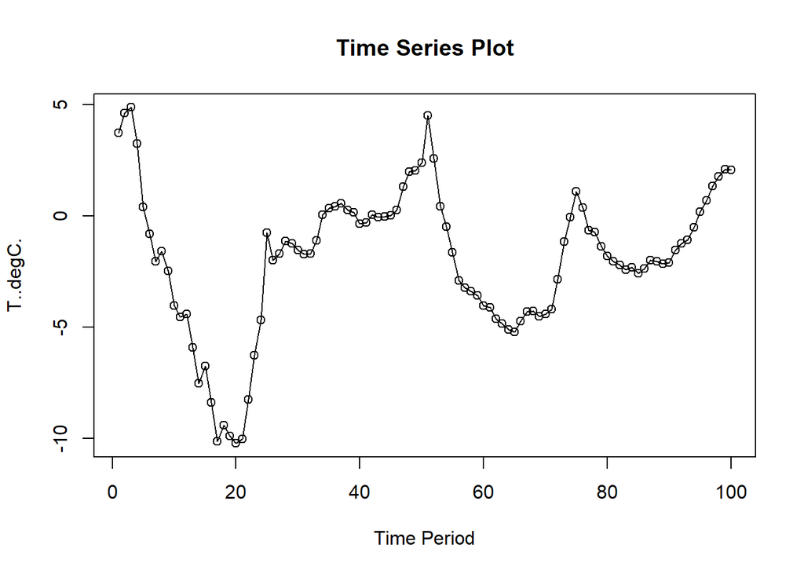

```r
ts.plot(dt.ts, xlab="Time Period", ylab="T..degC.",
        main = "Time Series Plot")
points(dt.ts)
```

## Moving Average

### Pembagian Data

Pembagian data latih dan data uji dilakukan dengan perbandingan 80% data latih dan 20% data uji.

```r
# hitung jumlah data
n <- nrow(dt)

# tentukan batas 80%
n_train <- floor(0.8 * n)

# bagi data
training_ma <- dt[1:n_train, ]
testing_ma  <- dt[(n_train+1):n, ]

# ubah ke time series
train_ma.ts <- ts(training_ma$T..degC.)
test_ma.ts  <- ts(testing_ma$T..degC.)
```

Eksplorasi data dilakukan pada keseluruhan data, data latih serta data uji menggunakan plot data deret waktu.

```r
#eksplorasi keseluruhan data
plot(dt.ts, col="red",main="Plot semua data")
points(dt.ts)
```

[output not shown]

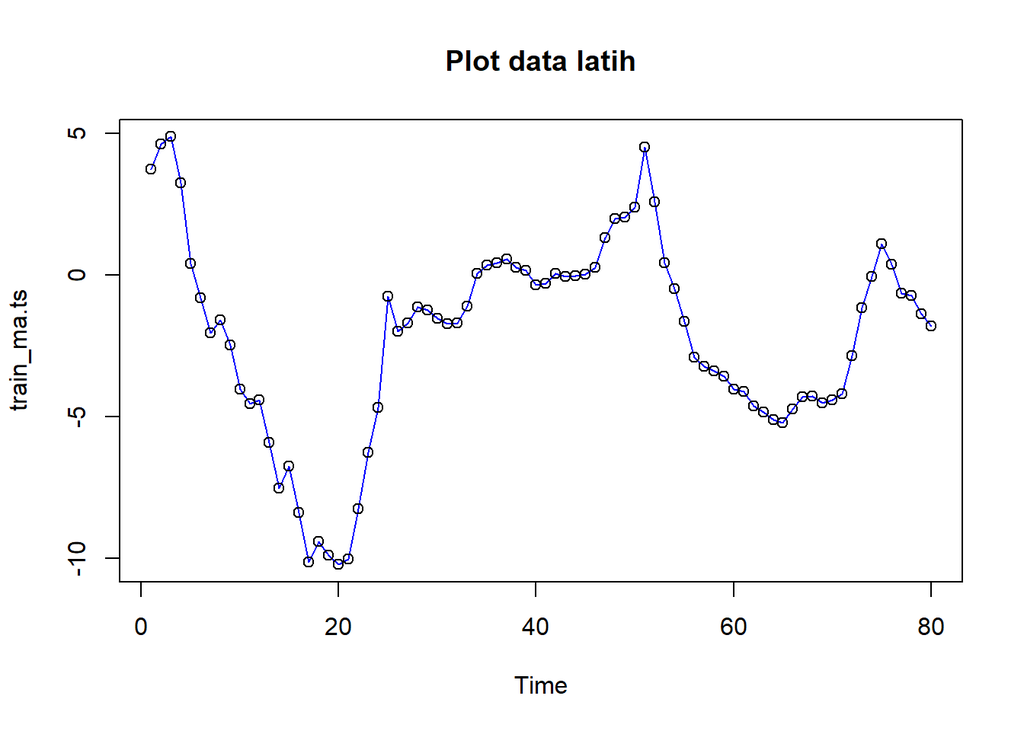

```r
#eksplorasi data latih
plot(train_ma.ts, col="blue",main="Plot data latih")
points(train_ma.ts)
```

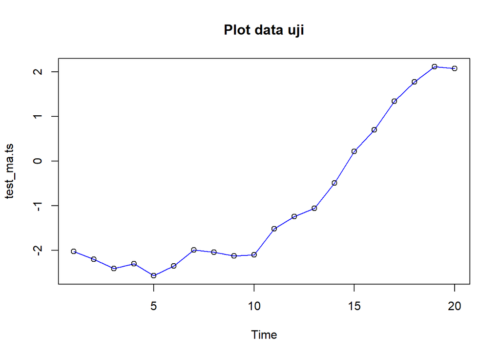

```r
#eksplorasi data uji
plot(test_ma.ts, col="blue",main="Plot data uji")
points(test_ma.ts)
```

```r
ggplot() +
  geom_line(data = training_ma, aes(x = Period, y = T..degC., col = "Data Latih")) +
  geom_line(data = testing_ma, aes(x = Period, y = T..degC., col = "Data Uji")) +
  labs(x = "Periode Waktu", y = "T..degC.", color = "Legend") +
   scale_colour_manual(name="Keterangan:", breaks = c("Data Latih", "Data Uji"),
                      values = c("blue", "red")) +
  theme_bw() + theme(legend.position = "bottom",
                     plot.caption = element_text(hjust=0.5, size=12))
```

[output not shown]

### Single Moving Average (SMA)

Pemulusan menggunakan metode SMA dilakukan dengan fungsi `SMA()`. Dalam hal ini akan dilakukan pemulusan dengan parameter `m=3`.

```r
data.sma<-SMA(train_ma.ts, n=3)
data.sma
```

```
## Time Series:
## Start = 1
## End = 80
## Frequency = 1
##  [1]            NA            NA   4.423333333   4.256666667   2.853333333
##  [6]   0.956666667  -0.803333333  -1.466666667  -2.020000000  -2.680000000
## [11]  -3.666666667  -4.316666667  -4.946666667  -5.946666667  -6.720000000
## [16]  -7.550000000  -8.413333333  -9.303333333  -9.800000000  -9.830000000
## [21] -10.033333333  -9.490000000  -8.173333333  -6.396666667  -3.893333333
## [26]  -2.470000000  -1.473333333  -1.603333333  -1.353333333  -1.293333333
## [31]  -1.490000000  -1.640000000  -1.503333333  -0.906666667  -0.220000000
## [36]   0.293333333   0.460000000   0.433333333   0.340000000   0.033333333
## [41]  -0.160000000  -0.196666667  -0.096666667  -0.003333333  -0.006666667
## [46]   0.106666667   0.553333333   1.203333333   1.786666667   2.140000000
## [51]   2.983333333   3.163333333   2.513333333   0.846666667  -0.556666667
## [56]  -1.666666667  -2.576666667  -3.156666667  -3.383333333  -3.656666667
## [61]  -3.900000000  -4.246666667  -4.516666667  -4.853333333  -5.053333333
## [66]  -5.016666667  -4.746666667  -4.433333333  -4.360000000  -4.390000000
## [71]  -4.363333333  -3.810000000  -2.730000000  -1.350000000  -0.026666667
## [76]   0.483333333   0.290000000  -0.323333333  -0.903333333  -1.286666667
```

Data pemulusan pada periode ke-t selanjutnya digunakan sebagai nilai peramalan pada periode ke t+1 sehingga hasil peramalan 1 periode kedepan adalah sebagai berikut.

```r
data.ramal<-c(NA,data.sma)
data.ramal #forecast 1 periode ke depan
```

```
##  [1]            NA            NA            NA   4.423333333   4.256666667
##  [6]   2.853333333   0.956666667  -0.803333333  -1.466666667  -2.020000000
## [11]  -2.680000000  -3.666666667  -4.316666667  -4.946666667  -5.946666667
## [16]  -6.720000000  -7.550000000  -8.413333333  -9.303333333  -9.800000000
## [21]  -9.830000000 -10.033333333  -9.490000000  -8.173333333  -6.396666667
## [26]  -3.893333333  -2.470000000  -1.473333333  -1.603333333  -1.353333333
## [31]  -1.293333333  -1.490000000  -1.640000000  -1.503333333  -0.906666667
## [36]  -0.220000000   0.293333333   0.460000000   0.433333333   0.340000000
## [41]   0.033333333  -0.160000000  -0.196666667  -0.096666667  -0.003333333
## [46]  -0.006666667   0.106666667   0.553333333   1.203333333   1.786666667
## [51]   2.140000000   2.983333333   3.163333333   2.513333333   0.846666667
## [56]  -0.556666667  -1.666666667  -2.576666667  -3.156666667  -3.383333333
## [61]  -3.656666667  -3.900000000  -4.246666667  -4.516666667  -4.853333333
## [66]  -5.053333333  -5.016666667  -4.746666667  -4.433333333  -4.360000000
## [71]  -4.390000000  -4.363333333  -3.810000000  -2.730000000  -1.350000000
## [76]  -0.026666667   0.483333333   0.290000000  -0.323333333  -0.903333333
## [81]  -1.286666667
```

Selanjutnya dilakukan peramalan sebanyak 20 periode sesuai dengan jumlah data uji. Pada metode SMA, seluruh hasil peramalan untuk 20 periode ke depan akan memiliki nilai yang sama dengan hasil ramalan satu periode ke depan.

```r
data.gab<-cbind(
  aktual=c(dt.ts),
  pemulusan=c(data.sma,rep(NA,20)),
  ramalan=c(data.ramal,rep(data.ramal[length(data.ramal)],19)))

data.gab #forecast 20 periode ke depan
```

```
##        aktual     pemulusan       ramalan
##   [1,]   3.75            NA            NA
##   [2,]   4.63            NA            NA
##   [3,]   4.89   4.423333333            NA
##   [4,]   3.25   4.256666667   4.423333333
##   [5,]   0.42   2.853333333   4.256666667
##   [6,]  -0.80   0.956666667   2.853333333
##   [7,]  -2.03  -0.803333333   0.956666667
##   [8,]  -1.57  -1.466666667  -0.803333333
##   [9,]  -2.46  -2.020000000  -1.466666667
##  [10,]  -4.01  -2.680000000  -2.020000000
##  [11,]  -4.53  -3.666666667  -2.680000000
##  [12,]  -4.41  -4.316666667  -3.666666667
##  [13,]  -5.90  -4.946666667  -4.316666667
##  [14,]  -7.53  -5.946666667  -4.946666667
```

[output cut: 86 more lines]

Adapun plot data deret waktu dari hasil peramalan yang dilakukan adalah sebagai berikut.

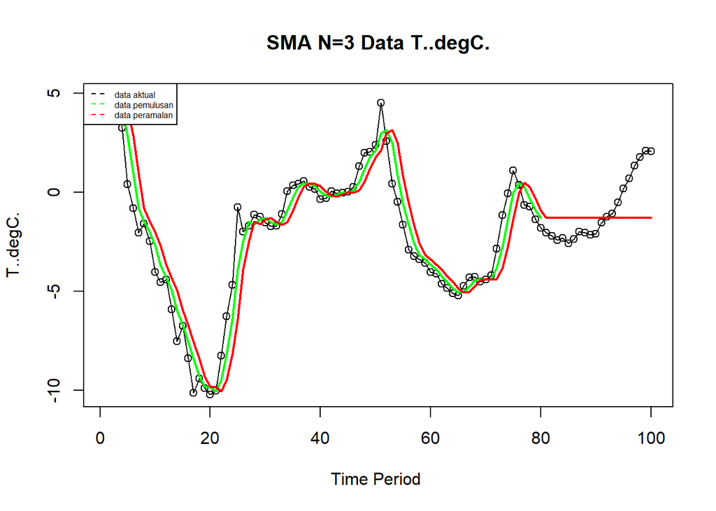

```r
ts.plot(dt.ts, xlab="Time Period ", ylab="T..degC.", main= "SMA N=3 Data T..degC.")
points(dt.ts)
lines(data.gab[,2],col="green",lwd=2)
lines(data.gab[,3],col="red",lwd=2)
legend("topleft",c("data aktual","data pemulusan","data peramalan"), lty=8, col=c("black","green","red"), cex=0.5)
```

Selanjutnya perhitungan akurasi dilakukan dengan ukuran akurasi *Sum Squares Error* (SSE), *Mean Square Error* (MSE) dan *Mean Absolute Percentage Error* (MAPE). Perhitungan akurasi dilakukan baik pada data latih maupun pada data uji.

$$SSE = \sum_{t=1}^{n} (y_t -
\hat{y}_t)^2$$

$$MSE = \frac{1}{n} \sum_{t=1}^{n} (y_t -
\hat{y}_t)^2$$

$$MAPE = \frac{1}{n} \sum_{t=1}^{n}
\left|\frac{y_t - \hat{y}_t}{y_t}\right| * 100$$

#### Akurasi Data Latih

```r
#Menghitung nilai keakuratan data latih
error_train.sma = train_ma.ts-data.ramal[1:length(train_ma.ts)]

SSE_train.sma = sum(error_train.sma[4:length(train_ma.ts)]^2)
MSE_train.sma = mean(error_train.sma[4:length(train_ma.ts)]^2)
MAPE_train.sma = mean(abs((error_train.sma[4:length(train_ma.ts)]/train_ma.ts[4:length(train_ma.ts)])*100))

akurasi_train.sma <- matrix(c(SSE_train.sma, MSE_train.sma, MAPE_train.sma))
row.names(akurasi_train.sma)<- c("SSE", "MSE", "MAPE")
colnames(akurasi_train.sma) <- c("Akurasi m = 3")
akurasi_train.sma
```

```
##      Akurasi m = 3
## SSE     208.214378
## MSE       2.704083
## MAPE    215.666431
```

#### Akurasi Data Uji

```r
#Menghitung nilai keakuratan data uji
error_test.sma = test_ma.ts-data.gab[81:100,3]

SSE_test.sma = sum(error_test.sma^2)
MSE_test.sma = mean(error_test.sma^2)
MAPE_test.sma = mean(abs((error_test.sma/test_ma.ts*100)))

akurasi_test.sma <- matrix(c(SSE_test.sma, MSE_test.sma, MAPE_test.sma))
row.names(akurasi_test.sma)<- c("SSE", "MSE", "MAPE")
colnames(akurasi_test.sma) <- c("Akurasi m = 3")
akurasi_test.sma
```

```
##      Akurasi m = 3
## SSE      54.864656
## MSE       2.743233
## MAPE    115.301057
```

### Double Moving Average (DMA)

Metode pemulusan Double Moving Average (DMA) pada dasarnya mirip dengan SMA. Namun demikian, metode ini lebih cocok digunakan untuk pola data trend. Proses pemulusan dengan rata rata dalam metode ini dilakukan sebanyak 2 kali.

- **Tahap I:**

$$S_{1,t} = \frac{1}{m} \sum_{i=t-m+1}^{t}
X_i$$

- **Tahap II:**

$$S_{2,t} = \frac{1}{m} \sum_{i=t-m+1}^{t}
S_{1,i}$$

Forecast $h$ langkah ke depan dihitung dengan:

$$F_{2,t,t+h} = A_t + B_t
\,(h)$$

dengan komponen level ($A_t$) dan tren ($B_t$):

$$A_t = 2S_{1,t} - S_{2,t}
\qquad\text{dan}\qquad
B_t = \frac{2}{m-1}\,\big(S_{1,t} - S_{2,t}\big)$$

```r
dma <- SMA(data.sma, n = 3)
At <- 2*data.sma - dma
Bt <- 2/(3-1)*(data.sma - dma)
data.dma<- At+Bt
data.ramal2<- c(NA, data.dma)

t = 1:20
f = c()

for (i in t) {
  f[i] = At[length(At)] + Bt[length(Bt)]*(i)
}

data.gab2 <- cbind(aktual = c(dt.ts),
                   pemulusan1 = c(data.sma,rep(NA,20)),
                   pemulusan2 = c(dma, rep(NA,20)),
                   At = c(At, rep(NA,20)),
                   Bt = c(Bt,rep(NA,20)),
                   ramalan = c(data.ramal2, f[-1]))
data.gab2
```

```
##        aktual    pemulusan1  pemulusan2           At           Bt      ramalan
##   [1,]   3.75            NA          NA           NA           NA           NA
##   [2,]   4.63            NA          NA           NA           NA           NA
##   [3,]   4.89   4.423333333          NA           NA           NA           NA
##   [4,]   3.25   4.256666667          NA           NA           NA           NA
##   [5,]   0.42   2.853333333  3.84444444   1.86222222 -0.991111111           NA
##   [6,]  -0.80   0.956666667  2.68888889  -0.77555556 -1.732222222   0.87111111
##   [7,]  -2.03  -0.803333333  1.00222222  -2.60888889 -1.805555556  -2.50777778
##   [8,]  -1.57  -1.466666667 -0.43777778  -2.49555556 -1.028888889  -4.41444444
##   [9,]  -2.46  -2.020000000 -1.43000000  -2.61000000 -0.590000000  -3.52444444
##  [10,]  -4.01  -2.680000000 -2.05555556  -3.30444444 -0.624444444  -3.20000000
##  [11,]  -4.53  -3.666666667 -2.78888889  -4.54444444 -0.877777778  -3.92888889
##  [12,]  -4.41  -4.316666667 -3.55444444  -5.07888889 -0.762222222  -5.42222222
##  [13,]  -5.90  -4.946666667 -4.31000000  -5.58333333 -0.636666667  -5.84111111
##  [14,]  -7.53  -5.946666667 -5.07000000  -6.82333333 -0.876666667  -6.22000000
```

[output cut: 86 more lines]

Hasil pemulusan menggunakan metode DMA divisualisasikan sebagai berikut

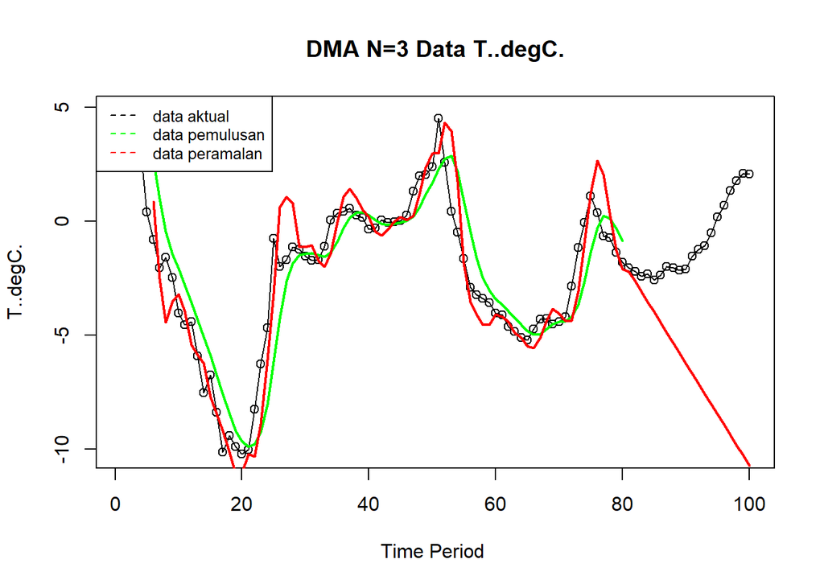

```r
ts.plot(dt.ts, xlab="Time Period ", ylab="T..degC.", main= "DMA N=3 Data T..degC.")
points(dt.ts)
lines(data.gab2[,3],col="green",lwd=2)
lines(data.gab2[,6],col="red",lwd=2)
legend("topleft",c("data aktual","data pemulusan","data peramalan"), lty=8, col=c("black","green","red"), cex=0.8)
```

Selanjutnya perhitungan akurasi dilakukan baik pada data latih maupun data uji. Perhitungan akurasi dilakukan dengan ukuran akurasi SSE, MSE dan MAPE.

#### Akurasi Data Latih

```r
#Menghitung nilai keakuratan data latih
error_train.dma = train_ma.ts-data.ramal2[1:length(train_ma.ts)]

SSE_train.dma = sum(error_train.dma[6:length(train_ma.ts)]^2)
MSE_train.dma = mean(error_train.dma[6:length(train_ma.ts)]^2)
MAPE_train.dma = mean(abs((error_train.dma[6:length(train_ma.ts)]/train_ma.ts[6:length(train_ma.ts)])*100))

akurasi_train.dma <- matrix(c(SSE_train.dma, MSE_train.dma, MAPE_train.dma))
row.names(akurasi_train.dma)<- c("SSE", "MSE", "MAPE")
colnames(akurasi_train.dma) <- c("Akurasi m = 3")
akurasi_train.dma
```

```
##      Akurasi m = 3
## SSE     115.354856
## MSE       1.538065
## MAPE    165.532073
```

#### Akurasi Data Uji

```r
#Menghitung nilai keakuratan data uji
error_test.dma = test_ma.ts-data.gab2[81:100,6]
SSE_test.dma = sum(error_test.dma^2)
MSE_test.dma = mean(error_test.dma^2)
MAPE_test.dma = mean(abs((error_test.dma/test_ma.ts*100)))

akurasi_test.dma <- matrix(c(SSE_test.dma, MSE_test.dma, MAPE_test.dma))
row.names(akurasi_test.dma)<- c("SSE", "MSE", "MAPE")
colnames(akurasi_test.dma) <- c("Akurasi m = 3")
akurasi_test.dma
```

```
##      Akurasi m = 3
## SSE      951.40749
## MSE       47.57037
## MAPE     602.72891
```

Berdasarkan hasil pengujian, DMA memiliki kemampuan penyesuaian yang lebih baik terhadap data latih dibandingkan SMA. Namun, performa DMA mengalami penurunan yang sangat besar pada data uji. Sebaliknya, SMA menghasilkan nilai error yang relatif stabil antara data latih dan data uji. Oleh karena itu, berdasarkan kemampuan peramalan pada data uji, SMA (m=3) lebih baik dibandingkan DMA (m=3).

## Exponential Smoothing

Metode Exponential Smoothing merupakan metode pemulusan deret waktu dengan memberikan bobot yang menurun secara eksponensial pada data historis, di mana nilai terbaru mendapat bobot lebih besar dibanding nilai yang lebih lama. Metode ini menggunakan satu atau lebih parameter pemulusan yang secara langsung menentukan besar kecilnya bobot setiap pengamatan. Pemilihan parameter yang tepat akan sangat berpengaruh terhadap hasil ramalan. Secara umum, Exponential Smoothing dibedakan menjadi dua jenis, yaitu model tunggal (single) yang digunakan untuk data tanpa tren maupun musiman, serta model ganda (double) yang mampu menangkap adanya tren pada data.

### Pembagian Data

Pembagian data latih dan data uji dilakukan dengan perbandingan 80% data latih dan 20% data uji.

```r
# jumlah baris data
n <- nrow(dt)

# hitung batas 80%
n_train <- floor(0.8 * n)

# bagi data
training <- dt[1:n_train, ]
testing  <- dt[(n_train+1):n, ]

# ubah ke time series
train.ts <- ts(training$T..degC.)
test.ts  <- ts(testing$T..degC.)
```

### Eksplorasi

Eksplorasi dilakukan dengan membuat plot data deret waktu untuk keseluruhan data, data latih, dan data uji.

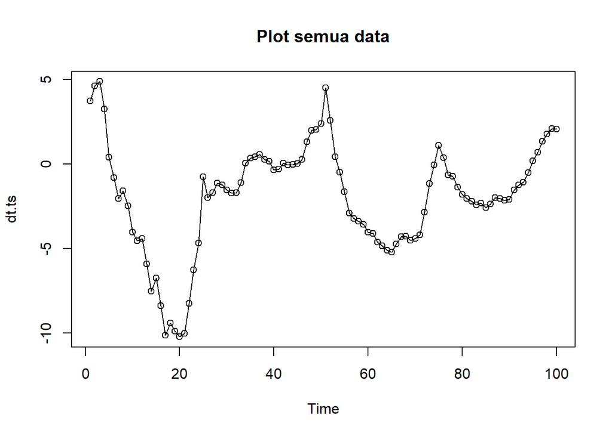

```r
#eksplorasi data
plot(dt.ts, col="black",main="Plot semua data")
points(dt.ts)
```

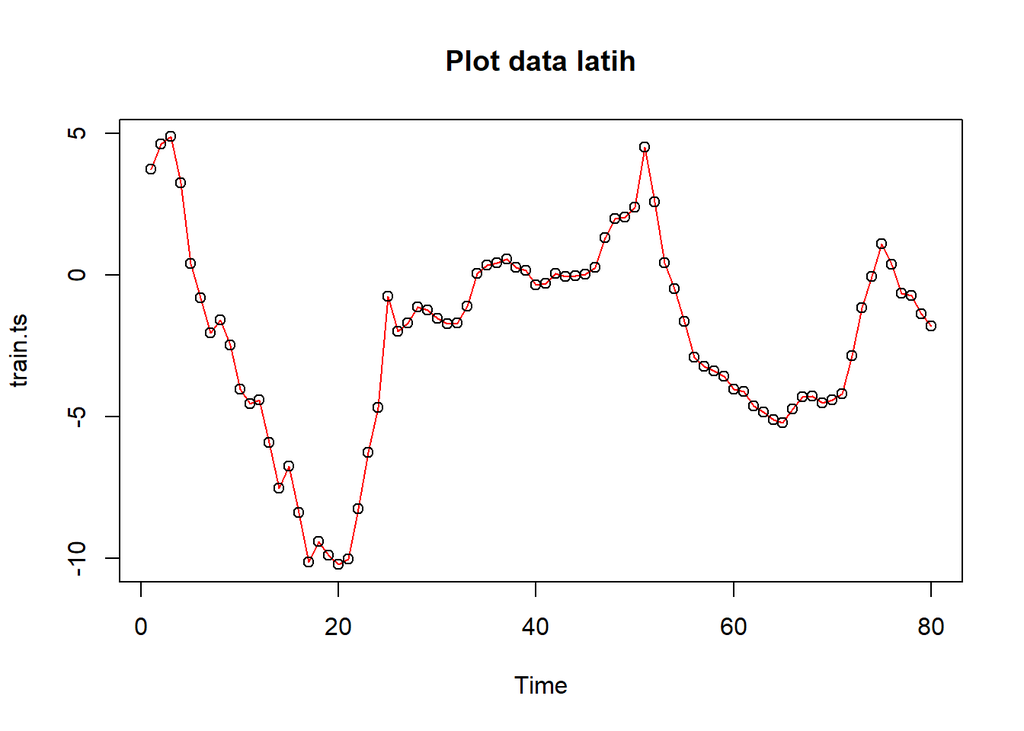

```r
plot(train.ts, col="red",main="Plot data latih")
points(train.ts)
```

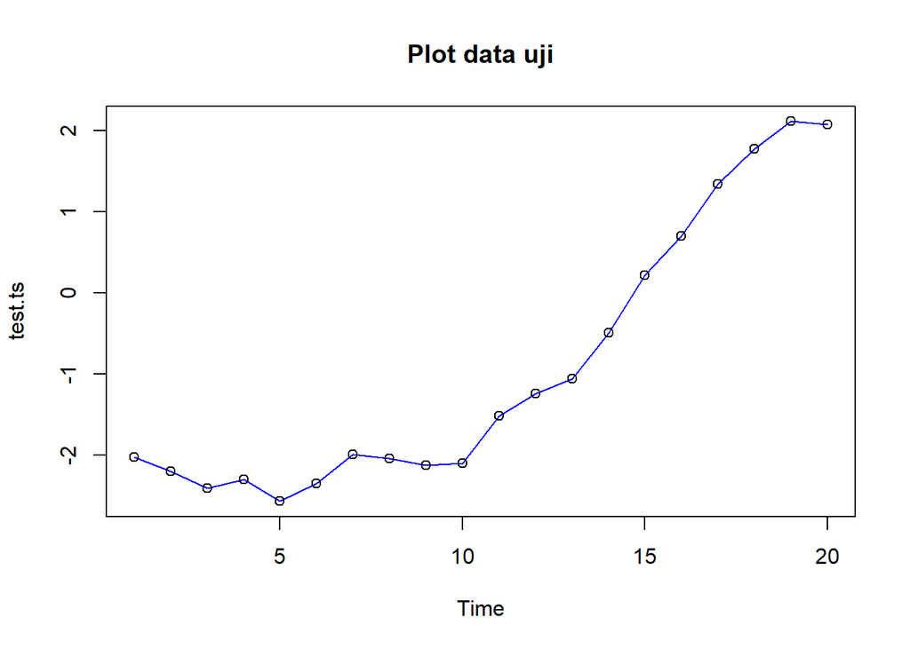

```r
plot(test.ts, col="blue",main="Plot data uji")
points(test.ts)
```

```r
ggplot() +
  geom_line(data = training, aes(x = Period, y = T..degC., col = "Data Latih")) +
  geom_line(data = testing, aes(x = Period, y = T..degC., col = "Data Uji")) +
  labs(x = "Periode Waktu", y = "T..degC.", color = "Legend") +
  scale_colour_manual(name="Keterangan:", breaks = c("Data Latih", "Data Uji"),
                      values = c("blue", "red")) +
  theme_bw() + theme(legend.position = "bottom",
                     plot.caption = element_text(hjust=0.5, size=12))
```

[output not shown]

### Single Exponential Smoothing

Single Exponential Smoothing (SES) adalah metode peramalan deret waktu yang dikembangkan untuk mengatasi kelemahan Moving Average. Jika pada Moving Average setiap data periode sebelumnya dianggap memiliki bobot yang sama, maka SES memberikan bobot yang semakin mengecil secara eksponensial terhadap data lama, sehingga data terbaru diberi bobot lebih besar.

Single Exponential Smoothing merupakan metode pemulusan yang tepat digunakan untuk data dengan pola stasioner atau konstan.

Nilai pemulusan pada periode ke-t didapat dari persamaan:

$$\tilde{y}_T=\lambda
y_t+(1-\lambda)\tilde{y}_{T-1}$$

Nilai parameter $\lambda$ adalah nilai antara 0 dan 1.

Nilai pemulusan periode ke-t bertindak sebagai nilai ramalan pada periode ke-$(T+\tau)$.

$$\tilde{y}_{T+\tau}(T)=\tilde{y}_T$$

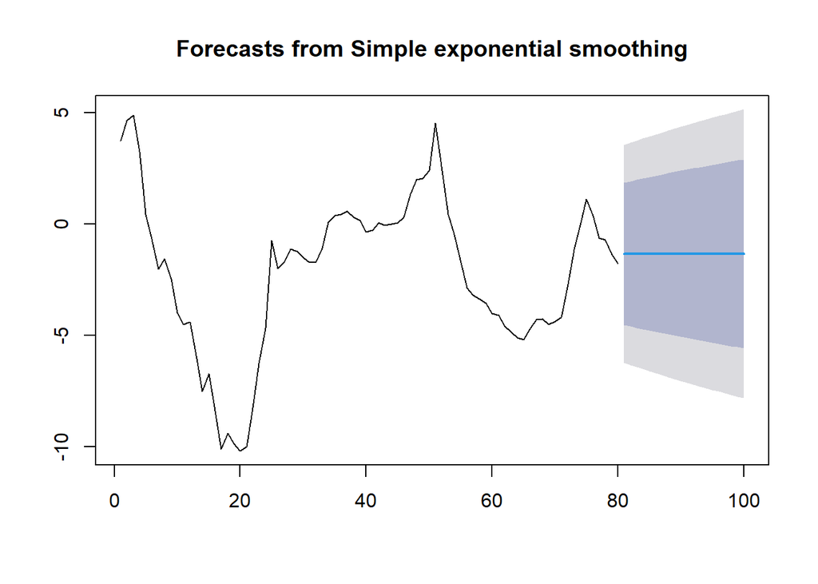

```r
#Cara 1 (fungsi ses)
ses.1 <- ses(train.ts, h = 20, alpha = 0.2)
plot(ses.1)
```

```r
ses.1
```

```
##     Point Forecast     Lo 80    Hi 80     Lo 95    Hi 95
##  81       -1.34451 -4.545521 1.856501 -6.240034 3.551014
##  82       -1.34451 -4.608913 1.919894 -6.336984 3.647965
##  83       -1.34451 -4.671098 1.982079 -6.432087 3.743068
##  84       -1.34451 -4.732141 2.043122 -6.525445 3.836426
##  85       -1.34451 -4.792104 2.103085 -6.617150 3.928131
##  86       -1.34451 -4.851042 2.162022 -6.707287 4.018268
##  87       -1.34451 -4.909005 2.219985 -6.795934 4.106915
##  88       -1.34451 -4.966040 2.277021 -6.883163 4.194143
##  89       -1.34451 -5.022191 2.333172 -6.969038 4.280019
##  90       -1.34451 -5.077498 2.388479 -7.053623 4.364603
##  91       -1.34451 -5.131997 2.442978 -7.136972 4.447952
##  92       -1.34451 -5.185723 2.496703 -7.219138 4.530119
##  93       -1.34451 -5.238708 2.549688 -7.300172 4.611152
##  94       -1.34451 -5.290981 2.601962 -7.380117 4.691097
##  95       -1.34451 -5.342571 2.653552 -7.459017 4.769998
##  96       -1.34451 -5.393504 2.704485 -7.536912 4.847893
##  97       -1.34451 -5.443804 2.754785 -7.613839 4.924820
##  98       -1.34451 -5.493494 2.804475 -7.689834 5.000814
##  99       -1.34451 -5.542596 2.853577 -7.764929 5.075910
## 100       -1.34451 -5.591131 2.902111 -7.839156 5.150137
```

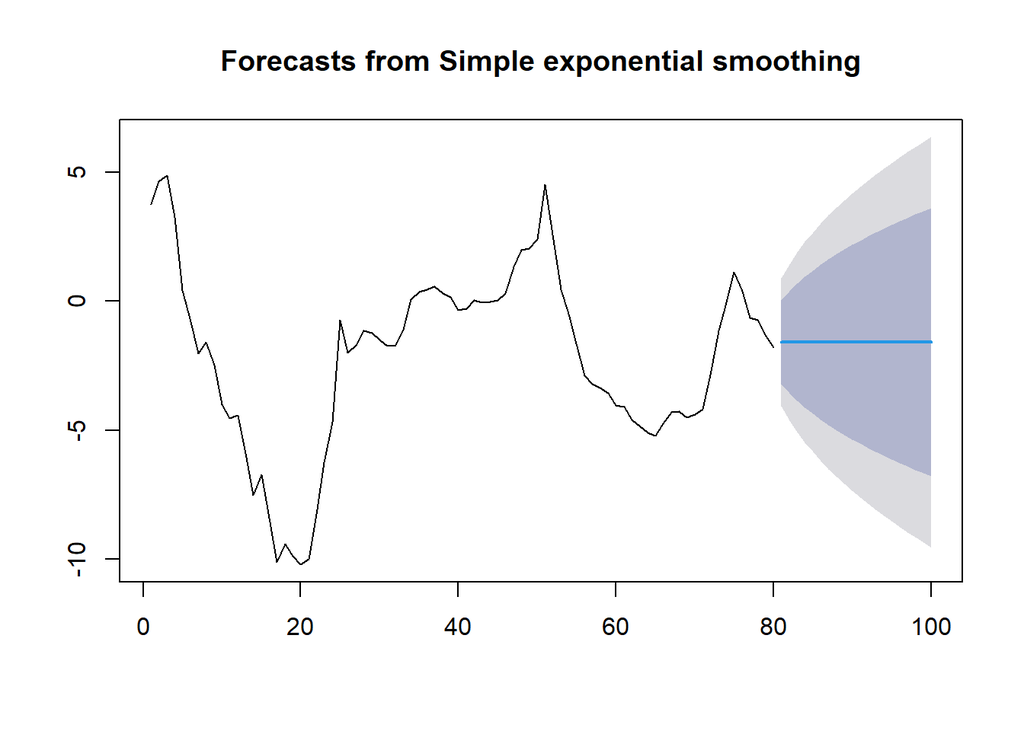

```r
ses.2<- ses(train.ts, h = 20, alpha = 0.7)
plot(ses.2)
```

```r
ses.2
```

```
##     Point Forecast     Lo 80      Hi 80     Lo 95    Hi 95
##  81      -1.585224 -3.205915 0.03546786 -4.063857 0.893410
##  82      -1.585224 -3.563529 0.39308243 -4.610781 1.440334
##  83      -1.585224 -3.865738 0.69529139 -5.072970 1.902523
##  84      -1.585224 -4.132340 0.96189292 -5.480702 2.310255
##  85      -1.585224 -4.373566 1.20311936 -5.849626 2.679179
##  86      -1.585224 -4.595524 1.42507711 -6.189081 3.018634
##  87      -1.585224 -4.802204 1.63175701 -6.505171 3.334724
##  88      -1.585224 -4.996384 1.82593722 -6.802144 3.631697
##  89      -1.585224 -5.180091 2.00964385 -7.083099 3.912652
##  90      -1.585224 -5.354855 2.18440846 -7.350378 4.179931
##  91      -1.585224 -5.521869 2.35142215 -7.605804 4.435356
##  92      -1.585224 -5.682080 2.51163296 -7.850825 4.680378
##  93      -1.585224 -5.836257 2.66581010 -8.086618 4.916171
##  94      -1.585224 -5.985035 2.81458792 -8.314154 5.143707
##  95      -1.585224 -6.128944 2.95849683 -8.534244 5.363797
##  96      -1.585224 -6.268433 3.09798568 -8.747574 5.577127
##  97      -1.585224 -6.403885 3.23343836 -8.954731 5.784284
##  98      -1.585224 -6.535633 3.36518618 -9.156222 5.985775
##  99      -1.585224 -6.663964 3.49351747 -9.352488 6.182041
## 100      -1.585224 -6.789132 3.61868500 -9.543915 6.373468
```

Pada fungsi `ses()` , terdapat beberapa argumen yang umum digunakan, yaitu

- `y` : nilai data deret waktu
- `alpha` : parameter pemulusan utama (0–1), mengatur bobot data terbaru vs data lama.
- `beta` : parameter pemulusan tren.
- `gamma` : parameter pemulusan musiman.
- `h` : jumlah periode ke depan yang ingin diramalkan (forecast horizon).

  Kasus di atas merupakan contoh inisialisasi nilai parameter $\lambda$ dengan nilai `alpha` 0,2 dan 0,7 dan banyak periode data yang akan diramalkan adalah sebanyak 20 periode.

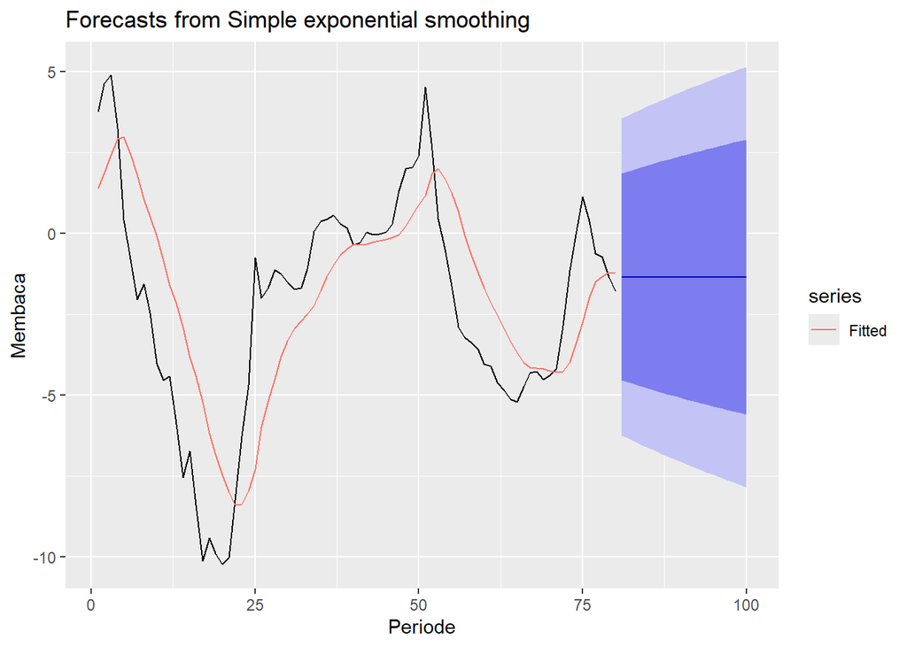

```r
autoplot(ses.1) +
  autolayer(fitted(ses.1), series="Fitted") +
  ylab("Membaca") + xlab("Periode")
```

Selanjutnya akan digunakan fungsi `HoltWinters()` dengan nilai inisialisasi parameter dan panjang periode peramalan yang sama dengan fungsi `ses()` .

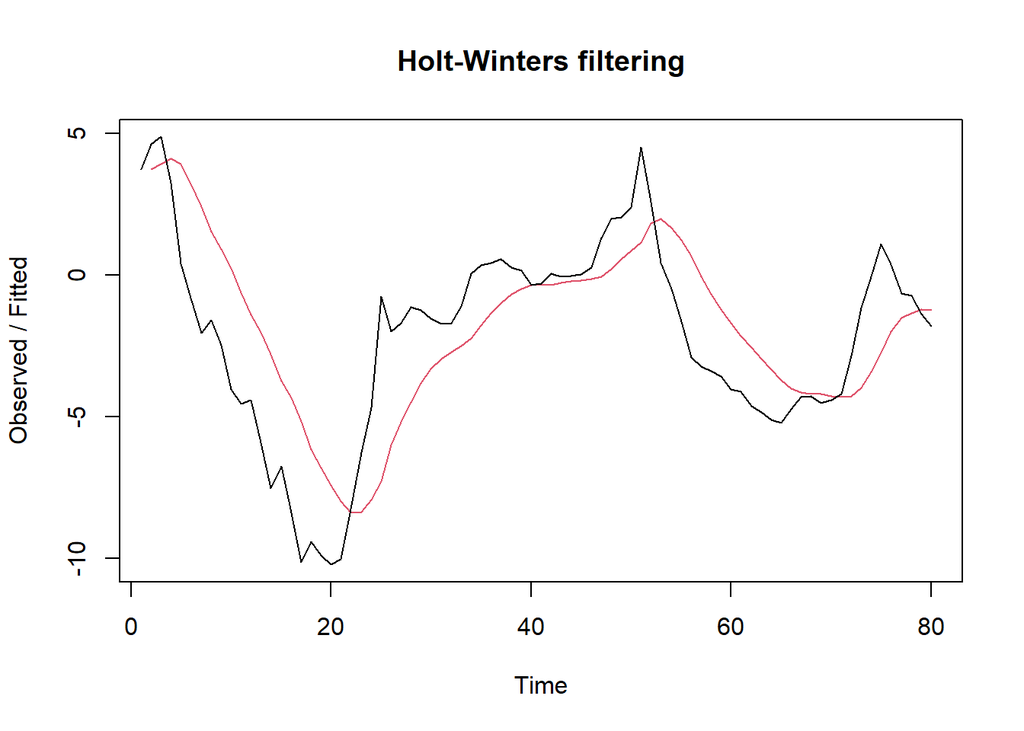

```r
#Cara 2 (fungsi Holtwinter)
ses1<- HoltWinters(train.ts, gamma = FALSE, beta = FALSE, alpha = 0.2)
plot(ses1)
```

```r
#ramalan
ramalan1 <- forecast(ses1, h=20)
ramalan1
```

```
##     Point Forecast     Lo 80    Hi 80     Lo 95    Hi 95
##  81       -1.34451 -4.569261 1.880242 -6.276341 3.587322
##  82       -1.34451 -4.633124 1.944104 -6.374011 3.684991
##  83       -1.34451 -4.695770 2.006750 -6.469819 3.780800
##  84       -1.34451 -4.757266 2.068246 -6.563870 3.874850
##  85       -1.34451 -4.817673 2.128654 -6.656255 3.967235
##  86       -1.34451 -4.877048 2.188028 -6.747060 4.058041
##  87       -1.34451 -4.935441 2.246421 -6.836365 4.147345
##  88       -1.34451 -4.992899 2.303880 -6.924240 4.235221
##  89       -1.34451 -5.049467 2.360447 -7.010753 4.321733
##  90       -1.34451 -5.105184 2.416164 -7.095964 4.406945
##  91       -1.34451 -5.160087 2.471068 -7.179931 4.490912
##  92       -1.34451 -5.214211 2.525192 -7.262708 4.573688
##  93       -1.34451 -5.267589 2.578570 -7.344342 4.655322
##  94       -1.34451 -5.320250 2.631231 -7.424880 4.735861
##  95       -1.34451 -5.372223 2.683203 -7.504365 4.815346
##  96       -1.34451 -5.423533 2.734514 -7.582838 4.893819
##  97       -1.34451 -5.474206 2.785187 -7.660336 4.971316
##  98       -1.34451 -5.524265 2.835246 -7.736894 5.047875
##  99       -1.34451 -5.573731 2.884712 -7.812546 5.123527
## 100       -1.34451 -5.622626 2.933606 -7.887324 5.198304
```

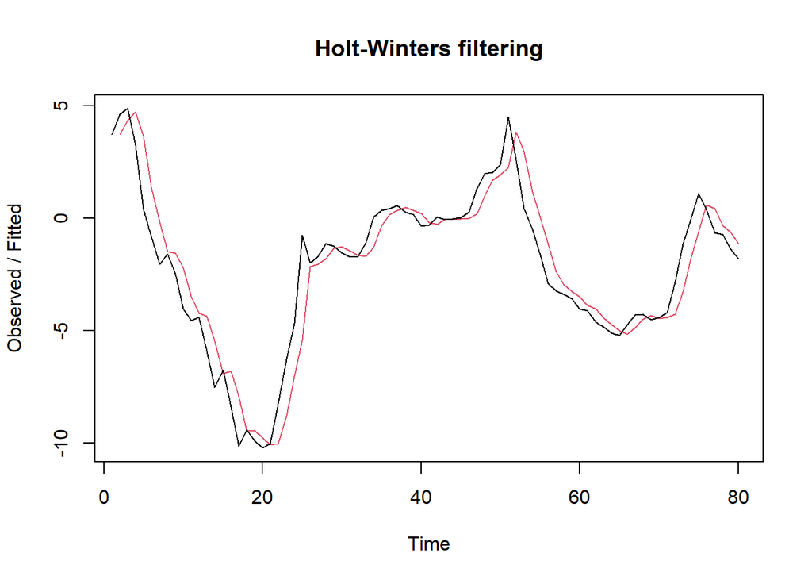

```r
ses2<- HoltWinters(train.ts, gamma = FALSE, beta = FALSE, alpha = 0.7)
plot(ses2)
```

```r
#ramalan
ramalan2<- forecast(ses2, h=20)
ramalan2
```

```
##     Point Forecast     Lo 80      Hi 80     Lo 95     Hi 95
##  81      -1.585224 -3.201466 0.03101913 -4.057053 0.8866063
##  82      -1.585224 -3.558099 0.38765206 -4.602476 1.4320293
##  83      -1.585224 -3.859478 0.68903147 -5.063396 1.8929493
##  84      -1.585224 -4.125348 0.95490118 -5.470009 2.2995620
##  85      -1.585224 -4.365912 1.19546547 -5.837920 2.6674733
##  86      -1.585224 -4.587261 1.41681395 -6.176444 3.0059966
##  87      -1.585224 -4.793374 1.62292653 -6.491666 3.3212186
##  88      -1.585224 -4.987021 1.81657372 -6.787823 3.6173764
##  89      -1.585224 -5.170223 1.99977609 -7.068007 3.8975602
##  90      -1.585224 -5.344508 2.17406098 -7.334553 4.1641060
##  91      -1.585224 -5.511063 2.34061622 -7.589277 4.4188302
##  92      -1.585224 -5.670834 2.50038725 -7.833626 4.6631789
##  93      -1.585224 -5.824588 2.65414119 -8.068772 4.8983253
##  94      -1.585224 -5.972958 2.80251062 -8.295684 5.1252368
##  95      -1.585224 -6.116472 2.94602450 -8.515169 5.3447223
##  96      -1.585224 -6.255577 3.08513046 -8.727914 5.5574665
##  97      -1.585224 -6.390658 3.22021133 -8.934502 5.7640549
##  98      -1.585224 -6.522045 3.35159750 -9.135440 5.9649927
##  99      -1.585224 -6.650024 3.47957653 -9.331167 6.1607197
## 100      -1.585224 -6.774847 3.60440048 -9.522068 6.3516215
```

Nilai parameter $\alpha$ dari kedua fungsi dapat dioptimalkan menyesuaikan dari *error*-nya paling minimumnya. Caranya adalah dengan membuat parameter $\alpha =$ `NULL` .

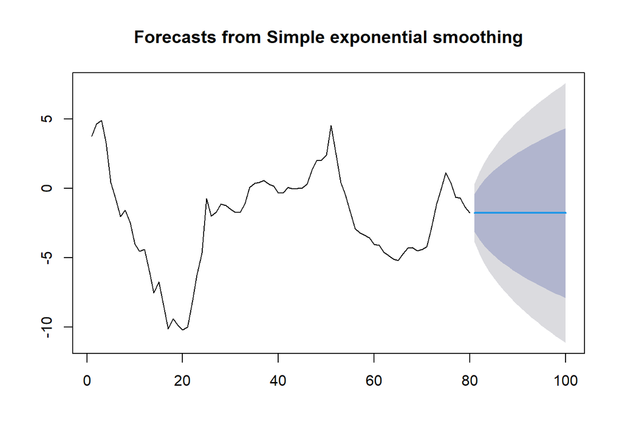

```r
#SES
ses.opt <- ses(train.ts, h = 20, alpha = NULL)
plot(ses.opt)
```

```r
ses.opt
```

```
##     Point Forecast     Lo 80      Hi 80      Lo 95     Hi 95
##  81      -1.779958 -3.148668 -0.4112483  -3.873219 0.3133028
##  82      -1.779958 -3.715509  0.1555930  -4.740128 1.1802118
##  83      -1.779958 -4.150475  0.5905586  -5.405350 1.8454343
##  84      -1.779958 -4.517172  0.9572560  -5.966166 2.4062496
##  85      -1.779958 -4.840241  1.2803250  -6.460257 2.9003409
##  86      -1.779958 -5.132319  1.5724029  -6.906951 3.3470355
##  87      -1.779958 -5.400913  1.8409970  -7.317731 3.7578147
##  88      -1.779958 -5.650915  2.0909988  -7.700075 4.1401595
##  89      -1.779958 -5.885722  2.3258060  -8.059182 4.4992661
##  90      -1.779958 -6.107808  2.5478924  -8.398834 4.8389180
##  91      -1.779958 -6.319042  2.7591257  -8.721887 5.1619714
##  92      -1.779958 -6.520873  2.9609567  -9.030561 5.4706453
##  93      -1.779958 -6.714455  3.1545393  -9.326620 5.7667044
##  94      -1.779958 -6.900725  3.3408090  -9.611495 6.0515793
##  95      -1.779958 -7.080453  3.5205369  -9.886365 6.3264494
##  96      -1.779958 -7.254283  3.6943673 -10.152216 6.5923001
##  97      -1.779958 -7.422761  3.8628453 -10.409881 6.8499650
##  98      -1.779958 -7.586353  4.0264368 -10.660073 7.1001566
##  99      -1.779958 -7.745460  4.1855438 -10.903406 7.3434898
## 100      -1.779958 -7.900432  4.3405161 -11.140415 7.5804994
```

```r
#Lamda Optimum Holt Winter
HWopt<- HoltWinters(train.ts, gamma = FALSE, beta = FALSE,alpha = NULL)
HWopt
```

```
## Holt-Winters exponential smoothing without trend and without seasonal component.
##
## Call:
## HoltWinters(x = train.ts, alpha = NULL, beta = FALSE, gamma = FALSE)
##
## Smoothing parameters:
##  alpha: 0.9999304
##  beta : FALSE
##  gamma: FALSE
##
## Coefficients:
##        [,1]
## a -1.779971
```

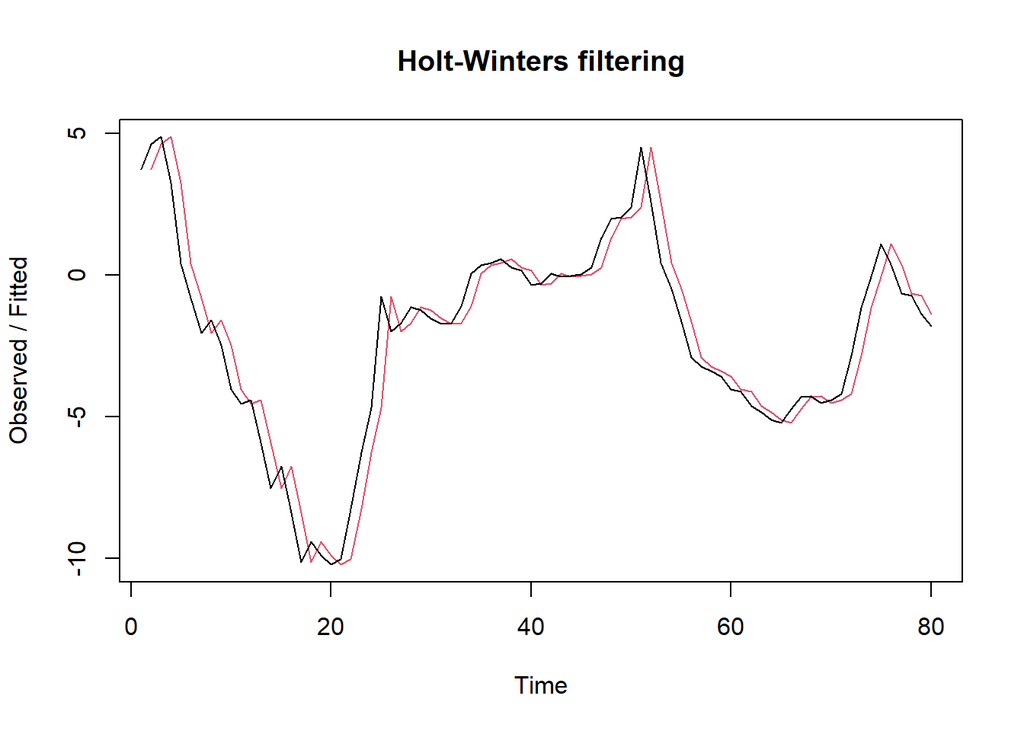

```r
plot(HWopt)
```

```r
#ramalan
ramalanopt<- forecast(HWopt, h=20)
ramalanopt
```

```
##     Point Forecast     Lo 80      Hi 80      Lo 95     Hi 95
##  81      -1.779971 -3.145683 -0.4142583  -3.868648 0.3087062
##  82      -1.779971 -3.711313  0.1513712  -4.733703 1.1737618
##  83      -1.779971 -4.145344  0.5854029  -5.397498 1.8375561
##  84      -1.779971 -4.511253  0.9513117  -5.957107 2.3971653
##  85      -1.779971 -4.833627  1.2736852  -6.450135 2.8901930
##  86      -1.779971 -5.125076  1.5651340  -6.895867 3.3359255
##  87      -1.779971 -5.393091  1.8331493  -7.305761 3.7458196
##  88      -1.779971 -5.642554  2.0826123  -7.687282 4.1273403
##  89      -1.779971 -5.876855  2.3169133  -8.045614 4.4856727
##  90      -1.779971 -6.098462  2.5385209  -8.384534 4.8245923
##  91      -1.779971 -6.309240  2.7492986  -8.706891 5.1469490
##  92      -1.779971 -6.510636  2.9506943  -9.014899 5.4549572
##  93      -1.779971 -6.703801  3.1438594  -9.310319 5.7503776
##  94      -1.779971 -6.889669  3.3297273  -9.594580 6.0346381
##  95      -1.779971 -7.069009  3.5090675  -9.868857 6.3089152
##  96      -1.779971 -7.242464  3.6825228 -10.134134 6.5741923
##  97      -1.779971 -7.410579  3.8506373 -10.391243 6.8313012
##  98      -1.779971 -7.573817  4.0138759 -10.640895 7.0809530
##  99      -1.779971 -7.732581  4.1726396 -10.883703 7.3237611
## 100      -1.779971 -7.887219  4.3272774 -11.120201 7.5602594
```

Setelah dilakukan peramalan, akan dilakukan perhitungan keakuratan hasil peramalan. Perhitungan akurasi ini dilakukan baik pada data latih dan data uji.

#### Akurasi Data Latih

Perhitungan akurasi data dapat dilakukan dengan cara langsung maupun manual. Secara langsung, nilai akurasi dapat diambil dari objek yang tersimpan pada hasil SES, yaitu *sum of squared errors* (SSE). Nilai akurasi lain dapat dihitung pula dari nilai SSE tersebut.

```r
#Keakuratan Metode
#Pada data training

# SES dengan alpha = 0.2
SSE1<-ses1$SSE
MSE1<-ses1$SSE/length(train.ts)
RMSE1<-sqrt(MSE1)

akurasi1 <- matrix(c(SSE1,MSE1,RMSE1))
row.names(akurasi1)<- c("SSE", "MSE", "RMSE")
colnames(akurasi1) <- c("Akurasi lamda=0.2")
akurasi1
```

```
##      Akurasi lamda=0.2
## SSE         502.085847
## MSE           6.276073
## RMSE          2.505209
```

```r
# SES dengan alpha = 0.7
SSE2<-ses2$SSE
MSE2<-ses2$SSE/length(train.ts)
RMSE2<-sqrt(MSE2)

akurasi2 <- matrix(c(SSE2,MSE2,RMSE2))
row.names(akurasi2)<- c("SSE", "MSE", "RMSE")
colnames(akurasi2) <- c("Akurasi lamda=0.7")
akurasi2
```

```
##      Akurasi lamda=0.7
## SSE         124.796408
## MSE           1.559955
## RMSE          1.248982
```

```r
#Cara Manual
# Alpha = 0.2
fitted1<-ramalan1$fitted
sisaan1<-ramalan1$residuals
head(sisaan1)
```

```
## Time Series:
## Start = 1
## End = 6
## Frequency = 1
## [1]        NA  0.880000  0.964000 -0.868800 -3.525040 -4.040032
```

```r
resid1<-training$T..degC.-ramalan1$fitted
head(resid1)
```

```
## Time Series:
## Start = 1
## End = 6
## Frequency = 1
## [1]        NA  0.880000  0.964000 -0.868800 -3.525040 -4.040032
```

```r
SSE.1=sum(sisaan1[2:length(train.ts)]^2)
SSE.1
```

```
## [1] 502.0858
```

```r
MSE.1 = SSE.1/length(train.ts)
MSE.1
```

```
## [1] 6.276073
```

```r
MAPE.1 = sum(abs(sisaan1[2:length(train.ts)]/train.ts[2:length(train.ts)])*
               100)/length(train.ts)
MAPE.1
```

```
## [1] 305.3629
```

```r
akurasi.1 <- matrix(c(SSE.1,MSE.1,MAPE.1))
row.names(akurasi.1)<- c("SSE", "MSE", "MAPE")
colnames(akurasi.1) <- c("Akurasi lamda=0.2")
akurasi.1
```

```
##      Akurasi lamda=0.2
## SSE         502.085847
## MSE           6.276073
## MAPE        305.362909
```

```r
# Alpha = 0.7
fitted2<-ramalan2$fitted
sisaan2<-ramalan2$residuals
head(sisaan2)
```

```
## Time Series:
## Start = 1
## End = 6
## Frequency = 1
## [1]        NA  0.880000  0.524000 -1.482800 -3.274840 -2.202452
```

```r
resid2<-training$T..degC.-ramalan2$fitted
head(resid2)
```

```
## Time Series:
## Start = 1
## End = 6
## Frequency = 1
## [1]        NA  0.880000  0.524000 -1.482800 -3.274840 -2.202452
```

```r
SSE.2=sum(sisaan2[2:length(train.ts)]^2)
SSE.2
```

```
## [1] 124.7964
```

```r
MSE.2 = SSE.2/length(train.ts)
MSE.2
```

```
## [1] 1.559955
```

```r
MAPE.2 = sum(abs(sisaan2[2:length(train.ts)]/train.ts[2:length(train.ts)])*
               100)/length(train.ts)
MAPE.2
```

```
## [1] 149.4646
```

```r
akurasi.2 <- matrix(c(SSE.2,MSE.2,MAPE.2))
row.names(akurasi.2)<- c("SSE", "MSE", "MAPE")
colnames(akurasi.2) <- c("Akurasi lamda=0.7")
akurasi.2
```

```
##      Akurasi lamda=0.7
## SSE         124.796408
## MSE           1.559955
## MAPE        149.464621
```

#### Akurasi Data Uji

Akurasi data uji dapat dihitung dengan cara yang hampir sama dengan perhitungan akurasi data latih.

```r
# jumlah observasi uji
n_test <- nrow(testing)

# error (ramalan - aktual), samakan panjang dan tipe numeric
e1   <- as.numeric(ramalan1$mean)[1:n_test] - as.numeric(testing$T..degC.)
e2   <- as.numeric(ramalan2$mean)[1:n_test] - as.numeric(testing$T..degC.)
eopt <- as.numeric(ramalanopt$mean)[1:n_test] - as.numeric(testing$T..degC.)

# SSE / MSE / RMSE untuk masing-masing model (abaikan NA)
SSEtesting1  <- sum(e1^2,  na.rm = TRUE)
MSEtesting1  <- mean(e1^2, na.rm = TRUE)
RMSEtesting1 <- sqrt(MSEtesting1)

SSEtesting2  <- sum(e2^2,  na.rm = TRUE)
MSEtesting2  <- mean(e2^2, na.rm = TRUE)
RMSEtesting2 <- sqrt(MSEtesting2)

SSEtestingopt  <- sum(eopt^2,  na.rm = TRUE)
MSEtestingopt  <- mean(eopt^2, na.rm = TRUE)
RMSEtestingopt <- sqrt(MSEtestingopt)

# Tabel ringkas
akurasitesting_SSE <- matrix(c(SSEtesting1, SSEtesting2, SSEtestingopt),
                             nrow = 3,
                             dimnames = list(c("SSE1","SSE2","SSEopt"), "Nilai"))
akurasitesting_MSE <- matrix(c(MSEtesting1, MSEtesting2, MSEtestingopt),
                             nrow = 3,
                             dimnames = list(c("MSE1","MSE2","MSEopt"), "Nilai"))
akurasitesting_RMSE <- matrix(c(RMSEtesting1, RMSEtesting2, RMSEtestingopt),
                              nrow = 3,
                              dimnames = list(c("RMSE1","RMSE2","RMSEopt"), "Nilai"))

akurasitesting_SSE
```

```
##           Nilai
## SSE1   55.79960
## SSE2   61.12772
## SSEopt 67.13448
```

```r
akurasitesting_MSE
```

```
##           Nilai
## MSE1   2.789980
## MSE2   3.056386
## MSEopt 3.356724
```

```r
akurasitesting_RMSE
```

```
##            Nilai
## RMSE1   1.670323
## RMSE2   1.748252
## RMSEopt 1.832137
```

Jadi berdasarkan MSE data uji, SES α=0,2 adalah yang terbaik dari tiga konfigurasi SES.

Selain dengan cara di atas, perhitungan nilai akurasi dapat menggunakan fungsi `accuracy()` dari *package* `forecast` . Penggunaannya yaitu dengan menuliskan `accuracy(hasil ramalan, kondisi aktual)` . Contohnya adalah sebagai berikut.

```r
accuracy(ramalan1, testing$T..degC.)
```

```
##                      ME     RMSE      MAE       MPE     MAPE     MASE     ACF1
## Training set -0.3224373 2.521015 2.071093 -26.56318 309.2283 2.712023 0.912162
## Test set      0.4330097 1.670323 1.318049  96.37175 117.3376 1.725939       NA
```

```r
accuracy(ramalan2, testing$T..degC.)
```

```
##                       ME     RMSE      MAE       MPE     MAPE     MASE
## Training set -0.09647782 1.256862 0.896148 -18.46491 151.3566 1.173474
## Test set      0.67372351 1.748252 1.300500  95.72217 126.2418 1.702959
##                   ACF1
## Training set 0.6255858
## Test set            NA
```

```r
accuracy(ramalanopt, testing$T..degC.)
```

```
##                      ME     RMSE      MAE       MPE     MAPE     MASE      ACF1
## Training set -0.0700045 1.061216 0.763691 -10.90226 123.2261 1.000026 0.3793382
## Test set      0.8684708 1.832137 1.300500  95.19663 134.3797 1.702959        NA
```

### *Double Exponential Smoothing* (DES)

Metode pemulusan *Double Exponential Smoothing* (DES) digunakan untuk data yang memiliki pola tren. Metode DES adalah metode semacam SES, hanya saja dilakukan dua kali, yaitu pertama untuk tahapan ‘level’ dan kedua untuk tahapan ‘tren’. Pemulusan menggunakan metode ini akan menghasilkan peramalan tidak konstan untuk periode berikutnya.

Pemulusan dengan metode DES kali ini akan menggunakan fungsi `HoltWinters()` . Jika sebelumnya nilai argumen `beta` dibuat `FALSE` , kali ini argumen tersebut akan diinisialisasi bersamaan dengan nilai `alpha` .

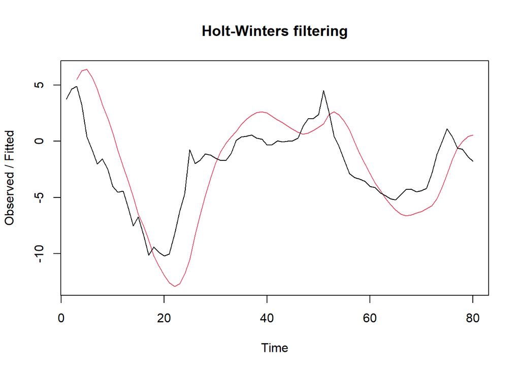

```r
#Lamda=0.2 dan gamma=0.2
des.1<- HoltWinters(train.ts, gamma = FALSE, beta = 0.2, alpha = 0.2)
plot(des.1)
```

```r
#ramalan
ramalandes1<- forecast(des.1, h=20)
ramalandes1
```

```
##     Point Forecast     Lo 80     Hi 80     Lo 95     Hi 95
##  81      0.5040878 -3.489247  4.497423 -5.603191  6.611366
##  82      0.9126609 -3.194072  5.019394 -5.368045  7.193367
##  83      1.3212340 -2.934994  5.577462 -5.188105  7.830573
##  84      1.7298071 -2.714113  6.173727 -5.066582  8.526196
##  85      2.1383802 -2.532285  6.809046 -5.004787  9.281547
##  86      2.5469533 -2.389300  7.483206 -5.002394 10.096301
##  87      2.9555264 -2.284119  8.195171 -5.057819 10.968872
##  88      3.3640995 -2.215148  8.943347 -5.168623 11.896822
##  89      3.7726726 -2.180478  9.725823 -5.331885 12.877230
##  90      4.1812457 -2.178070 10.540561 -5.544488 13.906979
##  91      4.5898188 -2.205894 11.385532 -5.803327 14.982965
##  92      4.9983919 -2.262014 12.258797 -6.105440 16.102224
##  93      5.4069650 -2.344632 13.158562 -6.448079 17.262009
##  94      5.8155381 -2.452112 14.083188 -6.828741 18.459818
##  95      6.2241112 -2.582980 15.031203 -7.245173 19.693396
##  96      6.6326843 -2.735921 16.001290 -7.695361 20.960730
##  97      7.0412574 -2.909761 16.992276 -8.177512 22.260027
##  98      7.4498305 -3.103459 18.003120 -8.690033 23.589694
##  99      7.8584036 -3.316086 19.032893 -9.231504 24.948311
## 100      8.2669767 -3.546817 20.080770 -9.800662 26.334615
```

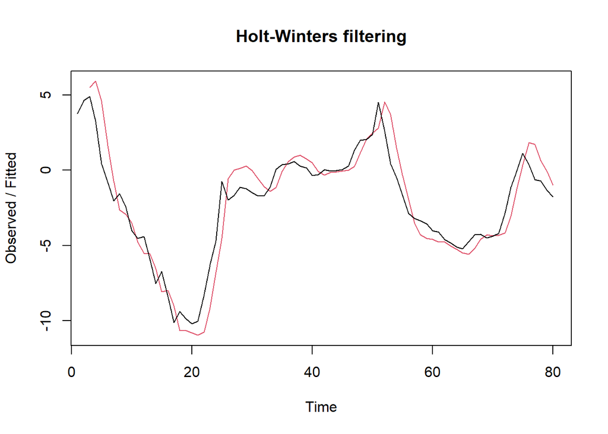

```r
#Lamda=0.6 dan gamma=0.3
des.2<- HoltWinters(train.ts, gamma = FALSE, beta = 0.3, alpha = 0.6)
plot(des.2)
```

```r
#ramalan
ramalandes2<- forecast(des.2, h=20)
ramalandes2
```

```
##     Point Forecast      Lo 80        Hi 80      Lo 95      Hi 95
##  81      -1.746926  -3.485277 -0.008574776  -4.405504  0.9116527
##  82      -2.029429  -4.234053  0.175195005  -5.401110  1.3422524
##  83      -2.311932  -5.076949  0.453084594  -6.540660  1.9167960
##  84      -2.594435  -5.996277  0.807407299  -7.797104  2.6082339
##  85      -2.876938  -6.980330  1.226454080  -9.152535  3.3986587
##  86      -3.159441  -8.021233  1.702350865 -10.594911  4.2760282
##  87      -3.441944  -9.113446  2.229557437 -12.115758  5.2318691
##  88      -3.724447 -10.252876  2.803980725 -13.708817  6.2599219
##  89      -4.006951 -11.436363  3.422461618 -15.369256  7.3553549
##  90      -4.289454 -12.661378  4.082470948 -17.093207  8.5143001
##  91      -4.571957 -13.925836  4.781922670 -18.877481  9.7335673
##  92      -4.854460 -15.227974  5.519054413 -20.719381 11.0104611
##  93      -5.136963 -16.566274  6.292348148 -22.616586 12.3426600
##  94      -5.419466 -17.939408  7.100475604 -24.567064 13.7281324
##  95      -5.701969 -19.346198  7.942259502 -26.569016 15.1650778
##  96      -5.984472 -20.785590  8.816645224 -28.620828 16.6518835
##  97      -6.266975 -22.256630  9.722679578 -30.721042 18.1870916
##  98      -6.549478 -23.758451 10.659494531 -32.868331 19.7693745
##  99      -6.831981 -25.290257 11.626294488 -35.061479 21.3975156
## 100      -7.114485 -26.851315 12.622346181 -37.299362 23.0703933
```

Selanjutnya jika ingin membandingkan plot data latih dan data uji adalah sebagai berikut.

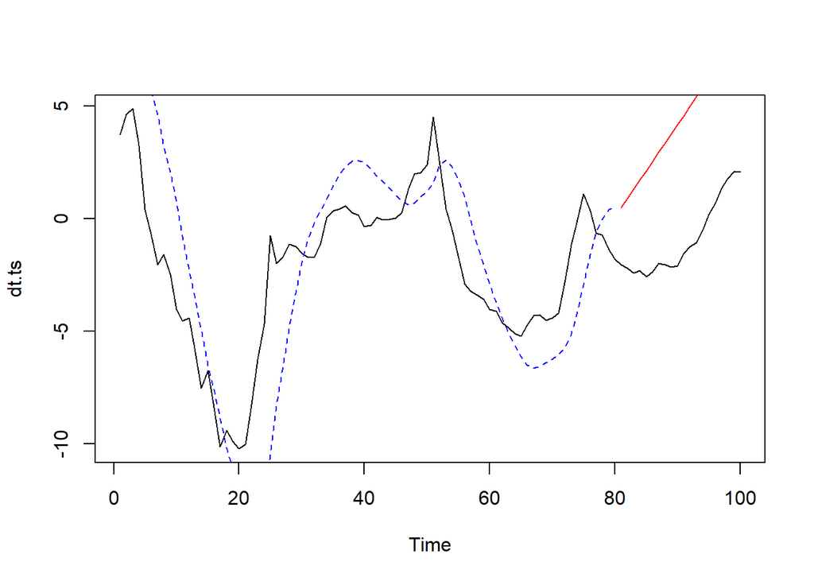

```r
plot(dt.ts)
lines(des.1$fitted[,1], lty=2, col="blue")
lines(ramalandes1$mean, col="red")
```

Untuk mendapatkan nilai parameter optimum dari DES, argumen `alpha` dan `beta` dapat dibuat `NULL` seperti berikut.

```r
#Lamda dan gamma optimum
des.opt<- HoltWinters(train.ts, gamma = FALSE)
des.opt
```

```
## Holt-Winters exponential smoothing with trend and without seasonal component.
##
## Call:
## HoltWinters(x = train.ts, gamma = FALSE)
##
## Smoothing parameters:
##  alpha: 1
##  beta : 0.4117719
##  gamma: FALSE
##
## Coefficients:
##         [,1]
## a -1.7800000
## b -0.3833612
```

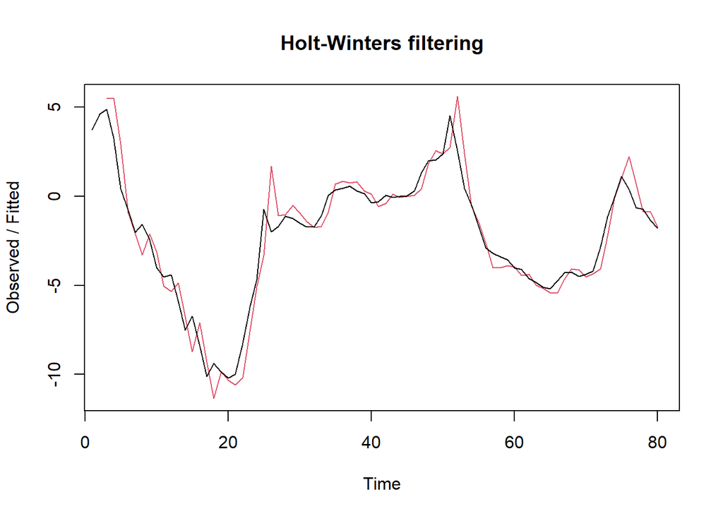

```r
plot(des.opt)
```

```r
#ramalan
ramalandesopt<- forecast(des.opt, h=20)
ramalandesopt
```

```
##     Point Forecast      Lo 80      Hi 80      Lo 95       Hi 95
##  81      -2.163361  -3.521825 -0.8048971  -4.240953 -0.08576961
##  82      -2.546722  -4.896944 -0.1965010  -6.141076  1.04763105
##  83      -2.930084  -6.344781  0.4846131  -8.152412  2.29224435
##  84      -3.313445  -7.883026  1.2561360 -10.302016  3.67512613
##  85      -3.696806  -9.511623  2.1180108 -12.589801  5.19618895
##  86      -4.080167 -11.227128  3.0667926 -15.010500  6.85016471
##  87      -4.463529 -13.025520  4.0984629 -17.557965  8.63090752
##  88      -4.846890 -14.902928  5.2091476 -20.226272 10.53249231
##  89      -5.230251 -16.855801  6.3952989 -23.009996 12.54949337
##  90      -5.613612 -18.880944  7.6537188 -25.904245 14.67701973
##  91      -5.996974 -20.975481  8.9815338 -28.904624 16.91067676
##  92      -6.380335 -23.136828 10.3761578 -32.007179 19.24650923
##  93      -6.763696 -25.362647 11.8352545 -35.208337 21.68094429
##  94      -7.147057 -27.650819 13.3567044 -38.504855 24.21074030
##  95      -7.530419 -29.999413 14.9385756 -41.893780 26.83294264
##  96      -7.913780 -32.406659 16.5790993 -45.372406 29.54484630
##  97      -8.297141 -34.870932 18.2766493 -48.938247 32.34396427
##  98      -8.680502 -37.390730 20.0297247 -52.589006 35.22800084
##  99      -9.063864 -39.964662 21.8369346 -56.322556 38.19482907
## 100      -9.447225 -42.591436 23.6969861 -60.136921 41.24247160
```

Selanjutnya akan dilakukan perhitungan akurasi pada data latih maupun data uji dengan ukuran akurasi SSE, MSE dan MAPE.

#### Akurasi Data Latih

```r
#Akurasi Data Training
ssedes.train1<-des.1$SSE
msedes.train1<-ssedes.train1/length(train.ts)
sisaandes1<-ramalandes1$residuals
head(sisaandes1)
```

```
## Time Series:
## Start = 1
## End = 6
## Frequency = 1
## [1]        NA        NA -0.620000 -2.991200 -5.958512 -6.484021
```

```r
mapedes.train1 <- sum(abs(sisaandes1[3:length(train.ts)]/train.ts[3:length(train.ts)])
                      *100)/length(train.ts)

akurasides.1 <- matrix(c(ssedes.train1,msedes.train1,mapedes.train1))
row.names(akurasides.1)<- c("SSE", "MSE", "MAPE")
colnames(akurasides.1) <- c("Akurasi lamda=0.2 dan gamma=0.2")
akurasides.1
```

```
##      Akurasi lamda=0.2 dan gamma=0.2
## SSE                       749.416473
## MSE                         9.367706
## MAPE                      601.719671
```

```r
ssedes.train2<-des.2$SSE
msedes.train2<-ssedes.train2/length(train.ts)
sisaandes2<-ramalandes2$residuals
head(sisaandes2)
```

```
## Time Series:
## Start = 1
## End = 6
## Frequency = 1
## [1]        NA        NA -0.620000 -2.656400 -4.182808 -2.430466
```

```r
mapedes.train2 <- sum(abs(sisaandes2[3:length(train.ts)]/train.ts[3:length(train.ts)])
                      *100)/length(train.ts)

akurasides.2 <- matrix(c(ssedes.train2,msedes.train2,mapedes.train2))
row.names(akurasides.2)<- c("SSE", "MSE", "MAPE")
colnames(akurasides.2) <- c("Akurasi lamda=0.6 dan gamma=0.3")
akurasides.2
```

```
##      Akurasi lamda=0.6 dan gamma=0.3
## SSE                       142.209844
## MSE                         1.777623
## MAPE                      168.444714
```

#### Akurasi Data Uji

```r
#Akurasi Data Testing
selisihdes1<-ramalandes1$mean-testing$T..degC.
selisihdes1
```

```
## Time Series:
## Start = 81
## End = 100
## Frequency = 1
##  [1] 2.534088 3.112661 3.731234 4.029807 4.708380 4.896953 4.945526 5.404100
##  [9] 5.902673 6.281246 6.109819 6.238392 6.466965 6.305538 6.014111 5.932684
## [17] 5.701257 5.679831 5.748404 6.196977
```

```r
SSEtestingdes1<-sum(selisihdes1^2)
MSEtestingdes1<-SSEtestingdes1/length(testing$T..degC.)
MAPEtestingdes1<-sum(abs(selisihdes1/testing$T..degC.)*100)/length(testing$T..degC.)

selisihdes2<-ramalandes2$mean-testing$T..degC.
selisihdes2
```

```
## Time Series:
## Start = 81
## End = 100
## Frequency = 1
##  [1]  0.2830742  0.1705711  0.0980680 -0.2944351 -0.3069382 -0.8094413
##  [7] -1.4519444 -1.6844475 -1.8769506 -2.1894537 -3.0519567 -3.6144598
## [13] -4.0769629 -4.9294660 -5.9119691 -6.6844722 -7.6069753 -8.3194784
## [19] -8.9419815 -9.1844846
```

```r
SSEtestingdes2<-sum(selisihdes2^2)
MSEtestingdes2<-SSEtestingdes2/length(testing$T..degC.)
MAPEtestingdes2<-sum(abs(selisihdes2/testing$T..degC.)*100)/length(testing$T..degC.)

selisihdesopt<-ramalandesopt$mean-testing$T..degC.
selisihdesopt
```

```
## Time Series:
## Start = 81
## End = 100
## Frequency = 1
##  [1]  -0.1333612  -0.3467225  -0.5200837  -1.0134450  -1.1268062  -1.7301675
##  [7]  -2.4735287  -2.8068900  -3.1002512  -3.5136125  -4.4769737  -5.1403350
## [13]  -5.7036962  -6.6570574  -7.7404187  -8.6137799  -9.6371412 -10.4505024
## [19] -11.1738637 -11.5172249
```

```r
SSEtestingdesopt<-sum(selisihdesopt^2)
MSEtestingdesopt<-SSEtestingdesopt/length(testing$T..degC.)
MAPEtestingdesopt<-sum(abs(selisihdesopt/testing$T..degC.)*100)/length(testing$T..degC.)

akurasitestingdes <-
  matrix(c(SSEtestingdes1,MSEtestingdes1,MAPEtestingdes1,SSEtestingdes2,MSEtestingdes2,
           MAPEtestingdes2,SSEtestingdesopt,MSEtestingdesopt,MAPEtestingdesopt),
         nrow=3,ncol=3)
row.names(akurasitestingdes)<- c("SSE", "MSE", "MAPE")
colnames(akurasitestingdes) <- c("des ske1","des ske2","des opt")
akurasitestingdes
```

```
##       des ske1  des ske2   des opt
## SSE  585.78544 448.54425 758.66812
## MSE   29.28927  22.42721  37.93341
## MAPE 495.45695 399.55608 534.89845
```

#### Perbandingan SES dan DES

```r
MSEfull <-
  matrix(c(MSEtesting1,MSEtesting2,MSEtestingopt,MSEtestingdes1,MSEtestingdes2,
           MSEtestingdesopt),nrow=3,ncol=2)
row.names(MSEfull)<- c("ske 1", "ske 2", "ske opt")
colnames(MSEfull) <- c("ses","des")
MSEfull
```

```
##              ses      des
## ske 1   2.789980 29.28927
## ske 2   3.056386 22.42721
## ske opt 3.356724 37.93341
```

SES lebih baik daripada DES karena menghasilkan MSE testing yang lebih kecil pada seluruh skenario parameter yang dibandingkan.

## Seasonal Smoothing

Selanjutnya melakukan pembagian data dan mengubahnya menjadi data deret waktu.

```r
#membagi data menjadi training dan testing
training<-dt[1:80,2]
testing<-dt[81:100,2]
training.ts<-ts(training, frequency = 12)
testing.ts<-ts(testing, frequency = 12)
```

Kemudian akan dilakukan eskplorasi dengan plot data deret waktu sebagai berikut.

```r
#Membuat plot time series
plot(dt.ts, col="red",main="Plot semua data")
points(dt.ts)
```

[output not shown]

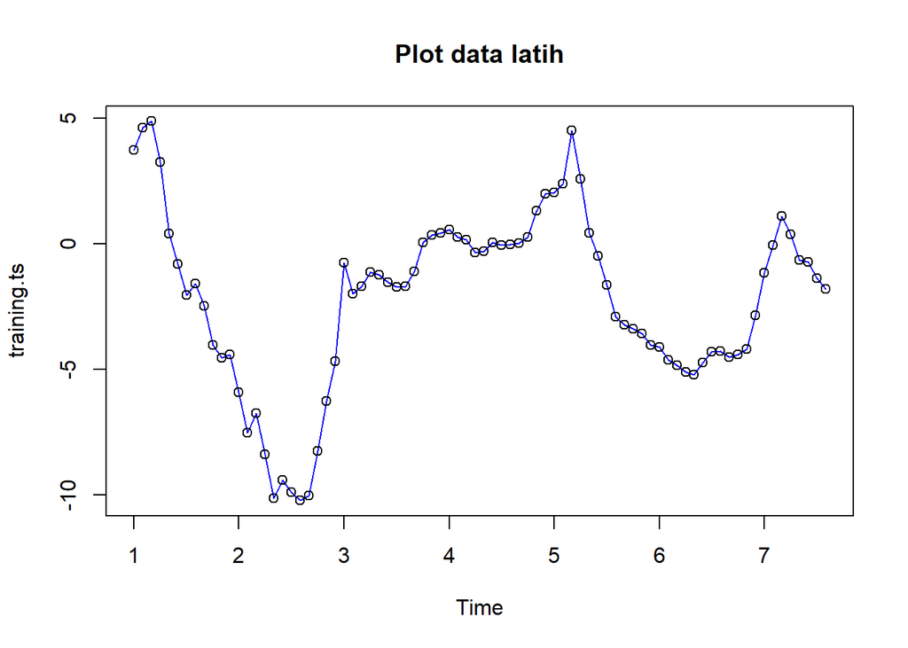

```r
plot(training.ts, col="blue",main="Plot data latih")
points(training.ts)
```

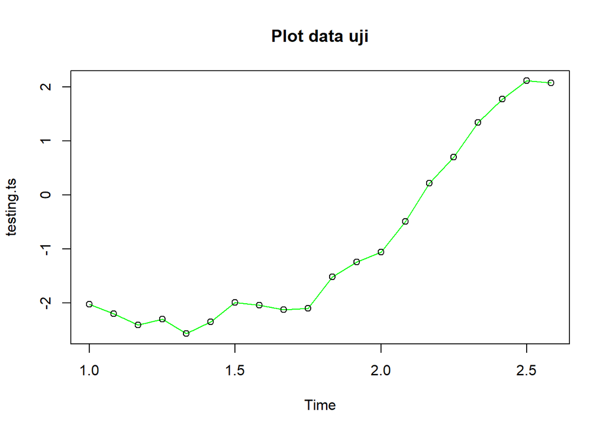

```r
plot(testing.ts, col="green",main="Plot data uji")
points(testing.ts)
```

Metode Holt-Winter untuk peramalan data musiman menggunakan tiga persamaan pemulusan yang terdiri atas persamaan untuk level $(L_t)$, trend $(B_t)$, dan komponen seasonal / musiman $(S_t)$ dengan parameter pemulusan berupa $\alpha$, $\beta$, dan $\gamma$. Metode Holt-Winter musiman terbagi menjadi dua, yaitu metode aditif dan metode multiplikatif. Perbedaan persamaan dan contoh datanya adalah sebagai berikut.

$$L_t = \alpha(Y_t - S_{t-s}) +
(1-\alpha)(L_{t-1} + B_{t-1})$$

$$B_t = \beta(L_t - L_{t-1}) +
(1-\beta)B_{t-1}$$
$$S_t = \gamma(Y_t
- L_t) + (1-\gamma)S_{t-s}$$

[figure not shown]

Pemulusan data musiman dengan metode Winter dilakukan menggunakan fungsi `HoltWinters()` dengan memasukkan argumen tambahan, yaitu `gamma()` dan `seasonal()` . Arguman `seasonal()` diinisialisasi menyesuaikan jenis musiman, aditif atau multiplikatif.

### Winter Aditif

Perhitungan dengan model aditif dilakukan jika plot data asli menunjukkan fluktuasi musiman yang relatif stabil (konstan).

#### Pemulusan

```r
#Pemulusan dengan winter aditif
winter1 <- HoltWinters(training.ts,alpha=0.2,beta=0.1,gamma=0.1,seasonal = "additive")
winter1$fitted
```

```
##               xhat        level       trend      season
## Jan 2  -0.75685096  -0.52115530 -0.70954983  0.47385417
## Feb 2  -3.54081024  -2.25933494 -0.81241281 -0.46906250
## Mar 2  -3.75626146  -3.86958569 -0.89219660  1.00552083
## Apr 2  -6.47143054  -5.35653000 -0.95167137 -0.16322917
## May 2  -9.32643719  -6.69191527 -0.99004276 -1.64447917
## Jun 2  -9.68773044  -7.84067059 -1.00591402 -0.84114583
## Jul 2 -10.72117709  -8.78903852 -1.00015941 -0.93197917
## Aug 2 -10.16752754  -9.62096251 -0.98333587  0.43677083
## Sep 2 -11.05937402 -10.61279287 -0.98418532  0.53760417
## Oct 2 -12.39353038 -11.38710338 -0.96319784 -0.04322917
## Nov 2 -12.04098487 -11.52159514 -0.88032723  0.36093750
## Dec 2 -10.73199542 -11.24572539 -0.76470753  1.27843750
## Jan 3 -11.38129922 -10.80003384 -0.64366762  0.06240224
## Feb 3 -10.53448094  -9.31544162 -0.43084164 -0.78819768
## Mar 3  -7.52971734  -8.03738707 -0.25995202  0.76762175
## Apr 3  -7.58926802  -7.12939562 -0.14315767 -0.31671472
## May 3  -7.70263619  -5.98069969 -0.01397231 -1.70796419
## Jun 3  -5.40499175  -4.70214476  0.11528041 -0.81812740
## Jul 3  -4.47937075  -3.80786600  0.19318025 -0.86468500
## Aug 3  -2.38107090  -3.06281160  0.24836766  0.43337304
## Sep 3  -1.79248659  -2.67622976  0.26218908  0.62155409
## Oct 3  -1.71125129  -2.27554336  0.27603881  0.28825326
## Nov 3  -0.50817417  -1.64325429  0.31166384  0.82341629
## Dec 3   0.93586883  -1.15595562  0.32922732  1.76259713
## Jan 4   0.30711406  -0.92590207  0.31930994  0.91370618
## Feb 4  -0.33408648  -0.55401493  0.32456766 -0.10463921
## Mar 4   1.46721855  -0.10462998  0.33704939  1.23479914
## Apr 4   0.48190745  -0.02902429  0.31090502  0.20002672
## May 4  -0.78118718   0.11549924  0.29426687 -1.19095330
## Jun 4   0.30556611   0.50800355  0.30409062 -0.50652806
## Jul 4   0.41602490   0.76098094  0.29897929 -0.64393534
## Aug 4   1.74507276   0.96675526  0.28965880  0.48865871
## Sep 4   1.83690986   0.90539950  0.25455734  0.67695302
## Oct 4   1.44994738   0.80057487  0.21861914  0.43075337
## Nov 4   1.87629496   0.78720454  0.19542020  0.89367022
## Dec 4   2.78078767   0.87336574  0.18449430  1.72292763
## Jan 5   2.00311811   0.89970251  0.16867854  0.93473706
## Feb 5   1.19046132   1.07575743  0.16941618 -0.05471229
## Mar 5   2.80870995   1.48508135  0.19340696  1.13022165
```

[output cut: 14 more lines]

```
## Jun 6  -6.27639542  -5.18593896 -0.36347684 -0.72697962
## Jul 6  -6.50661130  -5.24013672 -0.33254893 -0.93392565
## Aug 6  -5.46484013  -5.13136339 -0.28841671 -0.04506003
## Sep 6  -5.26730026  -5.18081207 -0.26451990  0.17803171
## Oct 6  -5.47962266  -5.29387192 -0.24937390  0.06362315
## Nov 6  -4.96689670  -5.32532129 -0.22758144  0.58600603
## Dec 6  -4.24489972  -5.39752339 -0.21204351  1.36466718
## Jan 7  -4.73723782  -5.33058696 -0.18414552  0.77749465
## Feb 7  -4.93882360  -4.79728491 -0.11240076 -0.02913793
## Mar 7  -2.82394283  -3.93192095 -0.01462429  1.12260240
## Apr 7  -2.96082136  -3.15775667  0.06425457  0.13268073
## May 7  -3.39997752  -2.42533783  0.13107100 -1.10571069
## Jun 7  -2.15706876  -1.74027133  0.18647055 -0.60326798
## Jul 7  -1.80857185  -1.26638703  0.21521192 -0.75739674
## Aug 7  -0.68675020  -0.96146073  0.22418336  0.05052718
```

```r
xhat1 <- winter1$fitted[,1]

winter1.opt<- HoltWinters(training.ts, alpha= NULL,  beta = NULL, gamma = NULL, seasonal = "additive")
winter1.opt
```

```
## Holt-Winters exponential smoothing with trend and additive seasonal component.
##
## Call:
## HoltWinters(x = training.ts, alpha = NULL, beta = NULL, gamma = NULL,     seasonal = "additive")
##
## Smoothing parameters:
##  alpha: 0.9543579
##  beta : 0.1743151
##  gamma: 1
##
## Coefficients:
##            [,1]
## a   -1.80646876
## b   -0.13699728
## s1   0.55459968
## s2   0.27770428
## s3   0.48176523
## s4   1.24505959
## s5   0.69113619
## s6  -0.30533904
## s7   0.79714138
## s8  -0.08723146
## s9  -1.47279964
## s10 -1.02968107
## s11 -1.02173909
## s12  0.02646876
```

```r
winter1.opt$fitted
```

```
##               xhat        level       trend      season
## Jan 2  -0.75685096  -0.52115530 -0.70954983  0.47385417
## Feb 2  -8.17333193  -6.13911024 -1.56515919 -0.46906250
## Mar 2  -7.54291477  -7.09030050 -1.45813510  1.00552083
## Apr 2  -9.25875249  -7.77262394 -1.32289938 -0.16322917
## May 2 -11.08927620  -8.26642249 -1.17837455 -1.64447917
## Jun 2 -10.37803311  -8.51976060 -1.01712668 -0.84114583
## Jul 2 -10.38989481  -8.60349362 -0.85442203 -0.93197917
## Aug 2  -9.30411906  -8.97129348 -0.76959641  0.43677083
## Sep 2 -10.98811829 -10.60542456 -0.92029790  0.53760417
## Oct 2 -11.39305575 -10.59224750 -0.75757908 -0.04322917
## Nov 2  -8.22399220  -8.35022638 -0.23470332  0.36093750
## Dec 2  -5.34011611  -6.71057816  0.09202455  1.27843750
## Jan 3  -5.54761549  -5.98856656  0.20184083  0.23911024
## Feb 3  -0.63660807  -1.19853972  1.00163116 -0.43969950
## Mar 3   0.33057721  -1.48852890  0.77648217  1.04262394
## Apr 3  -2.32363727  -2.64040063  0.44034087 -0.12357751
## May 3  -2.02222873  -1.06090256  0.63891323 -1.60023940
## Jun 3   0.29707454   0.32453687  0.76904405 -0.79650638
## Jul 3  -1.07130066  -0.63101501  0.46842086 -0.90870652
## Aug 3  -0.02575709  -0.78168551  0.36050386  0.39542456
## Sep 3  -1.34357558  -2.00946508  0.08364199  0.58224750
## Oct 3  -1.46897542  -1.69336480  0.12416300  0.10022638
## Nov 3   0.73029524  -0.10046839  0.38018548  0.45057816
## Dec 3   1.56468013  -0.06413354  0.32024711  1.30856656
## Jan 4  -0.22554772  -0.81723384  0.13314639  0.45853972
## Feb 4  -0.16082831   0.07514984  0.26549295 -0.50147110
## Mar 4   2.06178732   0.77089437  0.34049232  0.95040063
## Apr 4  -0.74858378  -0.70359913  0.02411280 -0.06909744
## May 4  -1.77321080  -0.29909474  0.09042081 -1.56453687
## Jun 4   0.66502142   1.20684007  0.33716635 -0.87898499
## Jul 4   0.25359332   0.95705584  0.23485197 -0.93831449
## Aug 4   1.40598267   0.90217112  0.18434648  0.31946508
## Sep 4   0.27731303  -0.26483671 -0.05121505  0.59336480
## Oct 4  -0.46275917  -0.54253334 -0.09069422  0.17046839
## Nov 4   0.55384174   0.08517413  0.03453408  0.43413354
## Dec 4   2.28132986   0.86044100  0.16365502  1.25723384
## Jan 5   1.35610288   0.74606306  0.11518967  0.49485016
## Feb 5   1.26200313   1.51393536  0.22896214 -0.48089437
## Mar 5   4.09962402   2.81941027  0.41661462  0.86359913
```

[output cut: 14 more lines]

```
## Jun 6  -4.74207114  -3.74379951 -0.01694626 -0.98132537
## Jul 6  -4.76107428  -3.74922559 -0.01493812 -0.99691057
## Aug 6  -3.10565028  -3.32413381  0.06176576  0.15671777
## Sep 6  -3.92417066  -4.37357445 -0.13193435  0.58133814
## Oct 6  -5.04623991  -5.06459968 -0.22939236  0.24775214
## Nov 6  -4.31171531  -4.66770428 -0.12022092  0.47620989
## Dec 6  -3.55904016  -4.67176523 -0.09997247  1.21269754
## Jan 7  -3.49287424  -4.09505959  0.01798277  0.58420258
## Feb 7  -1.81949766  -1.84113619  0.40774109 -0.38610256
## Mar 7   1.78494282   0.25533904  0.70211303  0.82749074
## Apr 7   0.84850445   0.32285862  0.59149378 -0.06584795
## May 7  -0.48541520   0.46723146  0.51355383 -1.46620049
## Jun 7   0.35152606   0.84279964  0.48950084 -0.98077441
## Jul 7  -0.35494233   0.30968107  0.31124279 -0.97586619
## Aug 7  -0.09064410  -0.33826091  0.14404235  0.10357445
```

```r
xhat1.opt <- winter1.opt$fitted[,1]
```

#### Peramalan

```r
#Forecast
forecast1 <- predict(winter1, n.ahead = 20)
forecast1.opt <- predict(winter1.opt, n.ahead = 20)
```

#### Plot Deret Waktu

[figure not shown]

```r
#Plot time series
plot(training.ts,main="Winter 0.2;0.1;0.3",type="l",col="black",
     xlim=c(1,15),pch=12)
lines(xhat1,type="l",col="red")
lines(xhat1.opt,type="l",col="blue")
lines(forecast1,type="l",col="red")
lines(forecast1.opt,type="l",col="blue")
legend("topleft",c("Actual Data",expression(paste(winter1)),
                   expression(paste(winter1.opt))),cex=0.5,
       col=c("black","red","blue"),lty=1)
```

#### Akurasi Data Latih

```r
#Akurasi data training
SSE1<-winter1$SSE
MSE1<-winter1$SSE/length(training.ts)
RMSE1<-sqrt(MSE1)
akurasi1 <- matrix(c(SSE1,MSE1,RMSE1))
row.names(akurasi1)<- c("SSE", "MSE", "RMSE")
colnames(akurasi1) <- c("Akurasi")
akurasi1
```

```
##         Akurasi
## SSE  687.944594
## MSE    8.599307
## RMSE   2.932458
```

```r
SSE1.opt<-winter1.opt$SSE
MSE1.opt<-winter1.opt$SSE/length(training.ts)
RMSE1.opt<-sqrt(MSE1.opt)
akurasi1.opt <- matrix(c(SSE1.opt,MSE1.opt,RMSE1.opt))
row.names(akurasi1.opt)<- c("SSE1.opt", "MSE1.opt", "RMSE1.opt")
colnames(akurasi1.opt) <- c("Akurasi")
akurasi1.opt
```

```
##              Akurasi
## SSE1.opt  138.396279
## MSE1.opt    1.729953
## RMSE1.opt   1.315277
```

```r
akurasi1.train = data.frame(Model_Winter = c("Winter 1","Winter1 optimal"),
                            Nilai_SSE=c(SSE1,SSE1.opt),
                            Nilai_MSE=c(MSE1,MSE1.opt),Nilai_RMSE=c(RMSE1,RMSE1.opt))
akurasi1.train
```

```
##      Model_Winter Nilai_SSE Nilai_MSE Nilai_RMSE
## 1        Winter 1  687.9446  8.599307   2.932458
## 2 Winter1 optimal  138.3963  1.729953   1.315277
```

Pada data latih, model Winter Aditif optimal jauh lebih baik karena MSE dan RMSE lebih kecil.

#### Akurasi Data Uji

```r
#Akurasi Data Testing
forecast1<-data.frame(forecast1)
testing.ts<-data.frame(testing.ts)
selisih1<-forecast1-testing.ts
SSEtesting1<-sum(selisih1^2)
MSEtesting1<-SSEtesting1/nrow(testing.ts)

forecast1.opt<-data.frame(forecast1.opt)
selisih1.opt<-forecast1.opt-testing.ts
SSEtesting1.opt<-sum(selisih1.opt^2)
MSEtesting1.opt<-SSEtesting1.opt/nrow(testing.ts)
```

```r
akurasi_testing <- data.frame(
  Model = c("Model1", "Model Optimum"),
  SSE   = c(SSEtesting1, SSEtesting1.opt),
  MSE   = c(MSEtesting1, MSEtesting1.opt)
)

akurasi_testing
```

```
##           Model      SSE       MSE
## 1        Model1 140.5901  7.029504
## 2 Model Optimum 205.3949 10.269745
```

Pada data uji, model Winter Aditif dengan parameter awal lebih baik karena MSE lebih kecil.

Model optimal mengalami penurunan performa ketika diterapkan pada data uji. Hal ini menunjukkan bahwa performa yang sangat baik pada data training belum tentu menghasilkan prediksi yang lebih baik pada data baru.

### Winter Multiplikatif

Model multiplikatif digunakan cocok digunakan jika plot data asli menunjukkan fluktuasi musiman yang bervariasi.

#### Pemulusan

```r
#Pemulusan dengan winter multiplikatif
winter2 <- HoltWinters(training.ts,alpha=0.2,beta=0.1,gamma=0.1,seasonal = "multiplicative")
winter2$fitted
```

```
##               xhat        level        trend    season
## Jan 2  -1.00054984  -0.52115530 -0.709549825 0.8129891
## Feb 2  -3.03629378  -2.43599810 -0.830079122 0.9296454
## Mar 2  -3.88967902  -4.23283423 -0.926754823 0.7538738
## Apr 2  -6.08818095  -5.91311596 -1.002107514 0.8804026
## May 2  -8.73878269  -7.43812492 -1.054397658 1.0289973
## Jun 2  -9.31032471  -8.76098146 -1.081243547 0.9459573
## Jul 2 -28.24866970  -9.86118470 -1.083139516 2.5811251
## Aug 2  -8.64004151  -9.52101700 -0.940808795 0.8258636
## Sep 2  -9.33142809 -10.84202379 -0.978828594 0.7894040
## Oct 2 -12.09891551 -11.99277245 -0.996020600 0.9314888
## Nov 2 -10.89165671 -12.16239225 -0.913380520 0.8329647
## Dec 2  -8.77382187 -11.96368317 -0.802171561 0.6872882
## Jan 3 -11.93756228 -11.57455780 -0.683041868 0.9738907
## Feb 3 -10.56288563  -9.95804751 -0.453086651 1.0145759
## Mar 3  -7.13489549  -8.72118947 -0.284092182 0.7923012
## Apr 3  -7.03985885  -7.63083076 -0.146647093 0.9051596
## May 3  -6.75768010  -6.47166200 -0.016065508 1.0416097
## Jun 3  -5.05377774  -5.42827502  0.089879741 0.9466848
## Jul 3 -10.73845978  -4.58972419  0.164746849 2.4267830
## Aug 3  -2.88305007  -3.68173332  0.239071252 0.8374479
## Sep 3  -2.29459666  -3.15773686  0.267563773 0.7939305
## Oct 3  -2.07656905  -2.58924080  0.297657001 0.9061720
## Nov 3  -1.18116262  -1.81781743  0.345033638 0.8019932
## Dec 3  -0.46277159  -1.08595693  0.383716324 0.6589929
## Jan 4  -0.01515109  -0.42825539  0.411114846 0.8839328
## Feb 4   0.50504171   0.11525664  0.424354565 0.9359363
## Mar 4   0.67156168   0.49365900  0.419759344 0.7352181
## Apr 4   0.98196856   0.77425917  0.405843427 0.8321044
## May 4   1.18479591   0.85995802  0.373828969 0.9602921
## Jun 4   1.12361729   0.92663130  0.343113400 0.8849159
## Jul 4   3.00256310   1.02709627  0.318848557 2.2308218
## Aug 4   1.10085332   1.07227321  0.291481395 0.8072224
## Sep 4   1.02385920   1.08852605  0.263958540 0.7570210
## Oct 4   1.07998927   1.09255541  0.237965622 0.8117040
## Nov 4   0.93143226   1.13587144  0.218500663 0.6877226
## Dec 4   0.83378003   1.47028156  0.230091608 0.4903512
## Jan 5   3.15969924   2.17196168  0.277250459 1.2900880
## Feb 5   2.28472503   2.27562720  0.259891966 0.9010877
## Mar 5   1.92501867   2.55888537  0.262228585 0.6823612
```

[output cut: 14 more lines]

```
## Jun 6  -4.90255975  -6.46208417 -0.498109065 0.7043712
## Jul 6 -12.81496544  -6.91119641 -0.493209383 1.7307217
## Aug 6  -2.64376316  -6.42042718 -0.394811522 0.3879194
## Sep 6 -34.08769488  -7.65367934 -0.478655585 4.1916246
## Oct 6  -7.00589816  -6.72105896 -0.337527989 0.9925355
## Nov 6  -5.53642672  -6.53147268 -0.284816562 0.8122347
## Dec 6  -4.02963392  -6.48475288 -0.251662925 0.5981866
## Jan 7  -8.10362860  -6.34201250 -0.212222595 1.2363958
## Feb 7  -5.09321899  -5.42941265 -0.099740351 0.9211572
## Mar 7  -3.36934398  -4.43417831  0.009757118 0.7615333
## Apr 7  -2.24670517  -3.24539354  0.127659884 0.7206213
## May 7  -1.67779597  -2.38872237  0.200561012 0.7667606
## Jun 7  -1.18488017  -1.91485677  0.227891471 0.7023738
## Jul 7  -2.13388155  -1.55459129  0.241128872 1.6246232
## Aug 7  -0.39177300  -1.21819337  0.250655777 0.4049176
```

```r
xhat2 <- winter2$fitted[,1]

winter2.opt<- HoltWinters(training.ts, alpha= NULL,  beta = NULL, gamma = NULL, seasonal = "multiplicative")
winter2.opt$fitted
```

```
##               xhat        level        trend    season
## Jan 2  -1.00054984  -0.52115530 -0.709549825 0.8129891
## Feb 2  -7.59900775  -7.25716997 -0.916922482 0.9296454
## Mar 2  -6.79559220  -8.09986227 -0.914368197 0.7538738
## Apr 2  -8.66192746  -8.92722360 -0.911374262 0.8804026
## May 2 -10.73293226  -9.52973070 -0.900746040 1.0289973
## Jun 2 -10.13599521  -9.83481700 -0.880249190 0.9459573
## Jul 2 -27.85163001  -9.93702346 -0.853476482 2.5811251
## Aug 2  -3.66821821  -3.82778815 -0.613887256 0.8258636
## Sep 2 -10.45902831 -12.36281576 -0.886456327 0.7894040
## Oct 2 -12.61919180 -12.68045269 -0.866883063 0.9314888
## Nov 2  -7.96503210  -8.85678907 -0.705479793 0.8329647
## Dec 2  -5.60165248  -7.51532478 -0.635043767 0.6872882
## Jan 3  -6.01471249  -6.80937008 -0.588899565 0.8129891
## Feb 3  -1.18610206  -0.91022132 -0.365643667 0.9296454
## Mar 3  -1.91182440  -2.14060105 -0.395399522 0.7538738
## Apr 3  -2.31284319  -2.24175451 -0.385274417 0.8804026
## May 3  -1.66959638  -1.28350366 -0.339043266 1.0289973
## Jun 3  -1.44706298  -1.20505663 -0.324677287 0.9459573
## Jul 3  -4.96410552  -1.59626653 -0.326966696 2.5811251
## Aug 3  -0.78464800  -0.66637608 -0.283717824 0.8258636
## Sep 3  -1.86913718  -2.04634267 -0.321440108 0.7894040
## Oct 3  -1.56617694  -1.39345634 -0.287913212 0.9314888
## Nov 3  -0.12687912   0.07514851 -0.227470842 0.8329647
## Dec 3   0.16306057   0.44419651 -0.206944430 0.6872882
## Jan 4   0.36350224   0.64019719 -0.193078956 0.8129891
## Feb 4   0.48041996   0.70111642 -0.184338794 0.9296454
## Mar 4   0.09088687   0.31194689 -0.191387087 0.7538738
## Apr 4   0.02113378   0.21223711 -0.188232441 0.8804026
## May 4  -0.61769009  -0.39754538 -0.202738118 1.0289973
## Jun 4  -0.44801268  -0.28182776 -0.191779950 0.9459573
## Jul 4  -0.31181961   0.05285651 -0.173664142 2.5811251
## Aug 4  -0.15653839  -0.01937140 -0.170173687 0.8258636
## Sep 4  -0.13907449  -0.01210854 -0.164068036 0.7894040
## Oct 4  -0.09835683   0.05067114 -0.156262131 0.9314888
## Nov 4   0.14111571   0.31132956 -0.141915757 0.8329647
## Dec 4   1.03361570   1.59670638 -0.092802145 0.6872882
## Jan 5   2.31744023   2.89543728 -0.044919031 0.8129891
## Feb 5   2.28004551   2.50925877 -0.056661883 0.9296454
## Mar 5   1.89846581   2.57087262 -0.052591975 0.7538738
```

[output cut: 14 more lines]

```
## Jun 6  -4.99760806  -5.06318148 -0.219940705 0.9459573
## Jul 6 -13.44877612  -5.00022563 -0.210206141 2.5811251
## Aug 6  -1.44871281  -1.66594019 -0.088239008 0.8258636
## Sep 6  -4.24394283  -5.17034508 -0.205790411 0.7894040
## Oct 6  -5.52424932  -5.71317099 -0.217387915 0.9314888
## Nov 6  -4.07184174  -4.71288533 -0.175487362 0.8329647
## Dec 6  -3.58117995  -5.03022537 -0.180368560 0.6872882
## Jan 7  -3.48812358  -4.14673178 -0.143760710 0.8129891
## Feb 7  -1.35666052  -1.41453313 -0.044797993 0.9296454
## Mar 7  -0.03785697  -0.05378395  0.003567352 0.7538738
## Apr 7   1.35764880   1.48565980  0.056417369 0.8804026
## May 7   0.46287065   0.43162070  0.018206193 1.0289973
## Jun 7  -0.59650802  -0.61224651 -0.018340106 0.9459573
## Jul 7  -2.02351427  -0.76113371 -0.022832275 2.5811251
## Aug 7  -0.44670025  -0.52690201 -0.013986618 0.8258636
```

```r
xhat2.opt <- winter2.opt$fitted[,1]
```

#### Peramalan

```r
#Forecast
forecast2 <- predict(winter2, n.ahead = 20)
forecast2.opt <- predict(winter2.opt, n.ahead = 20)
```

#### Plot Deret Waktu

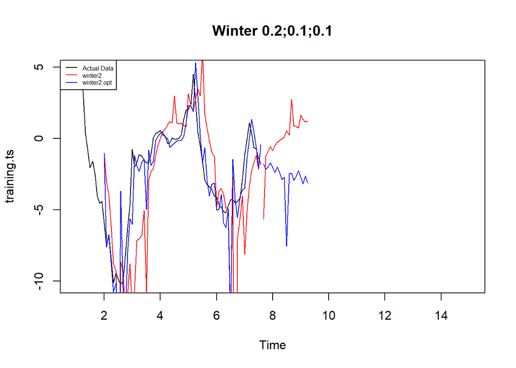

```r
#Plot time series
plot(training.ts,main="Winter 0.2;0.1;0.1",type="l",col="black",
     xlim=c(1,15),pch=12)
lines(xhat2,type="l",col="red")
lines(xhat2.opt,type="l",col="blue")
lines(forecast2,type="l",col="red")
lines(forecast2.opt,type="l",col="blue")
legend("topleft",c("Actual Data",expression(paste(winter2)),
                   expression(paste(winter2.opt))),cex=0.5,
       col=c("black","red","blue"),lty=1)
```

#### Akurasi Data Latih

```r
#Akurasi data training
SSE2<-winter2$SSE
MSE2<-winter2$SSE/length(training.ts)
RMSE2<-sqrt(MSE2)
akurasi1 <- matrix(c(SSE2,MSE2,RMSE2))
row.names(akurasi1)<- c("SSE2", "MSE2", "RMSE2")
colnames(akurasi1) <- c("Akurasi lamda=0.2")
akurasi1
```

```
##       Akurasi lamda=0.2
## SSE2        2090.313906
## MSE2          26.128924
## RMSE2          5.111646
```

```r
SSE2.opt<-winter2.opt$SSE
MSE2.opt<-winter2.opt$SSE/length(training.ts)
RMSE2.opt<-sqrt(MSE2.opt)
akurasi1.opt <- matrix(c(SSE2.opt,MSE2.opt,RMSE2.opt))
row.names(akurasi1.opt)<- c("SSE2.opt", "MSE2.opt", "RMSE2.opt")
colnames(akurasi1.opt) <- c("Akurasi")
akurasi1.opt
```

```
##              Akurasi
## SSE2.opt  600.093529
## MSE2.opt    7.501169
## RMSE2.opt   2.738826
```

```r
akurasi2.train = data.frame(Model_Winter = c("Winter 1","winter 2 optimal"),
                            Nilai_SSE=c(SSE2,SSE2.opt),
                            Nilai_MSE=c(MSE2,MSE2.opt),Nilai_RMSE=c(RMSE2,RMSE2.opt))
akurasi2.train
```

```
##       Model_Winter Nilai_SSE Nilai_MSE Nilai_RMSE
## 1         Winter 1 2090.3139 26.128924   5.111646
## 2 winter 2 optimal  600.0935  7.501169   2.738826
```

Pada data latih, model optimal lebih baik karena MSE dan RMSE lebih kecil.

#### Akurasi Data Uji

```r
#Akurasi Data Testing
forecast2<-data.frame(forecast2)
testing.ts<-data.frame(testing.ts)
selisih2<-forecast2-testing.ts
SSEtesting2<-sum(selisih2^2)
MSEtesting2<-SSEtesting2/nrow(testing.ts)

forecast2.opt<-data.frame(forecast2.opt)
selisih2.opt<-forecast2.opt-testing.ts
SSEtesting2.opt<-sum(selisih2.opt^2)
MSEtesting2.opt<-SSEtesting2.opt/nrow(testing.ts)
```

```r
# Atau rapikan dalam tabel
akurasi_testing2 <- data.frame(
  Model = c("Model2", "Model2 Optimal"),
  SSE   = c(SSEtesting2, SSEtesting2.opt),
  MSE   = c(MSEtesting2, MSEtesting2.opt)
)

akurasi_testing2
```

```
##            Model       SSE      MSE
## 1         Model2  67.09697 3.354849
## 2 Model2 Optimal 154.48854 7.724427
```

Pada data uji, model non-optimal justru lebih baik. Hal ini menunjukkan pola yang sama dengan Winter Aditif, yaitu model optimal berdasarkan training tidak otomatis menjadi model terbaik untuk forecasting testing.

Jika dibandingkan berdasarkan nilai MSE data uji, model Winter Multiplikatif awal memberikan hasil yang lebih baik dibandingkan model Winter Aditif awal. Winter Multiplikatif menghasilkan MSE sebesar 3,354849, sedangkan Winter Aditif menghasilkan MSE sebesar 7,029504. Dengan demikian, berdasarkan hasil pengujian pada data uji, model Winter Multiplikatif awal merupakan model yang lebih akurat dalam melakukan peramalan dibandingkan model Winter Aditif yang diuji.

## Kesimpulan

Berdasarkan hasil perhitungan akurasi pada data latih dan data uji, diperoleh perbedaan performa pada masing-masing metode peramalan. Pada data latih, metode DMA dengan parameter $m=3$ menghasilkan nilai MSE terkecil, yaitu sebesar 1,538065. Hal ini menunjukkan bahwa DMA mampu memberikan kecocokan yang baik terhadap data latih. Namun, pada data uji, MSE DMA meningkat secara signifikan menjadi 47,570370, sehingga menunjukkan bahwa performa DMA dalam melakukan peramalan pada data yang belum digunakan dalam proses pelatihan kurang baik.

Berbeda dengan DMA, metode SMA dengan $m=3$ menghasilkan nilai MSE data latih sebesar 2,704083 dan MSE data uji sebesar 2,743233. Nilai MSE yang relatif berdekatan antara data latih dan data uji menunjukkan bahwa SMA memiliki performa yang lebih stabil dalam melakukan peramalan. Selain SMA, metode SES dengan $\lambda=0,2$ juga menghasilkan performa yang baik pada data uji dengan MSE sebesar 2,789980, yang nilainya hanya sedikit lebih besar dibandingkan SMA. Winter Multiplikatif model pertama juga memberikan hasil yang cukup baik dengan MSE data uji sebesar 3,354849.

Sementara itu, metode DES menghasilkan nilai MSE data uji yang relatif lebih besar, yaitu 29,289270 untuk skenario $\lambda=0,2$ dan $\gamma=0,2$, serta 22,427210 untuk skenario $\lambda=0,6$ dan $\gamma=0,3$. Pada metode Winter Aditif, MSE data uji yang diperoleh sebesar 7,029504 untuk model pertama dan 10,269745 untuk model optimal. Adapun pada Winter Multiplikatif, model pertama menghasilkan MSE sebesar 3,354849, sedangkan model optimal menghasilkan MSE sebesar 7,724427.

Berdasarkan perbandingan nilai MSE pada data uji, metode **SMA dengan $m=3$ merupakan metode terbaik** karena menghasilkan nilai MSE paling kecil, yaitu sebesar **2,743233**. Hasil tersebut menunjukkan bahwa SMA memiliki kemampuan generalisasi yang lebih baik dibandingkan metode lainnya pada data penelitian ini. Dengan demikian, pemilihan metode peramalan sebaiknya tidak hanya didasarkan pada nilai akurasi data latih, tetapi juga mempertimbangkan performa model pada data uji sebagai representasi kemampuan model dalam meramalkan data yang belum diamati.

# Tugas-Pertemuan-2

Nama: Tasya Revadea Putri NIM: M0401241070

## Library/Packages

```r
library(forecast)
library(graphics)
library(TTR)
library(TSA)
library(rio)
library(readxl)
library(ggplot2)
```

## Input Data

```r
data <- read.csv("C:/Users/User/Downloads/data mpdw latihan prak 2.csv")

# menampilkan 5 data pertama
head(data)
```

```
##             Date.Time p..mbar. T..degC. Tpot..K. Tdew..degC. rh....
## 1 01.01.2009 00:10:00   996.52    -8.02   265.40       -8.90   93.3
## 2 01.01.2009 00:20:00   996.57    -8.41   265.01       -9.28   93.4
## 3 01.01.2009 00:30:00   996.53    -8.51   264.91       -9.31   93.9
## 4 01.01.2009 00:40:00   996.51    -8.31   265.12       -9.07   94.2
## 5 01.01.2009 00:50:00   996.51    -8.27   265.15       -9.04   94.1
## 6 01.01.2009 01:00:00   996.50    -8.05   265.38       -8.78   94.4
##   VPmax..mbar. VPact..mbar. VPdef..mbar. sh..g.kg. H2OC..mmol.mol. rho..g.m..3.
## 1         3.33         3.11         0.22      1.94            3.12      1307.75
## 2         3.23         3.02         0.21      1.89            3.03      1309.80
## 3         3.21         3.01         0.20      1.88            3.02      1310.24
## 4         3.26         3.07         0.19      1.92            3.08      1309.19
## 5         3.27         3.08         0.19      1.92            3.09      1309.00
## 6         3.33         3.14         0.19      1.96            3.15      1307.86
##   wv..m.s. max..wv..m.s. wd..deg.
## 1     1.03          1.75    152.3
## 2     0.72          1.50    136.1
## 3     0.19          0.63    171.6
## 4     0.34          0.50    198.0
## 5     0.32          0.63    214.3
## 6     0.21          0.63    192.7
```

```r
str(data)
```

```
## 'data.frame':    420551 obs. of  15 variables:
##  $ Date.Time      : chr  "01.01.2009 00:10:00" "01.01.2009 00:20:00" "01.01.2009 00:30:00" "01.01.2009 00:40:00" ...
##  $ p..mbar.       : num  997 997 997 997 997 ...
##  $ T..degC.       : num  -8.02 -8.41 -8.51 -8.31 -8.27 -8.05 -7.62 -7.62 -7.91 -8.43 ...
##  $ Tpot..K.       : num  265 265 265 265 265 ...
##  $ Tdew..degC.    : num  -8.9 -9.28 -9.31 -9.07 -9.04 -8.78 -8.3 -8.36 -8.73 -9.34 ...
##  $ rh....         : num  93.3 93.4 93.9 94.2 94.1 94.4 94.8 94.4 93.8 93.1 ...
##  $ VPmax..mbar.   : num  3.33 3.23 3.21 3.26 3.27 3.33 3.44 3.44 3.36 3.23 ...
##  $ VPact..mbar.   : num  3.11 3.02 3.01 3.07 3.08 3.14 3.26 3.25 3.15 3 ...
##  $ VPdef..mbar.   : num  0.22 0.21 0.2 0.19 0.19 0.19 0.18 0.19 0.21 0.22 ...
##  $ sh..g.kg.      : num  1.94 1.89 1.88 1.92 1.92 1.96 2.04 2.03 1.97 1.88 ...
##  $ H2OC..mmol.mol.: num  3.12 3.03 3.02 3.08 3.09 3.15 3.27 3.26 3.16 3.02 ...
##  $ rho..g.m..3.   : num  1308 1310 1310 1309 1309 ...
##  $ wv..m.s.       : num  1.03 0.72 0.19 0.34 0.32 0.21 0.18 0.19 0.28 0.59 ...
##  $ max..wv..m.s.  : num  1.75 1.5 0.63 0.5 0.63 0.63 0.63 0.5 0.75 0.88 ...
##  $ wd..deg.       : num  152 136 172 198 214 ...
```

```r
dim(data)
```

```
## [1] 420551     15
```

```r
data2 <- data[, c("Date.Time", "T..degC.")]

head(data2)
```

```
##             Date.Time T..degC.
## 1 01.01.2009 00:10:00    -8.02
## 2 01.01.2009 00:20:00    -8.41
## 3 01.01.2009 00:30:00    -8.51
## 4 01.01.2009 00:40:00    -8.31
## 5 01.01.2009 00:50:00    -8.27
## 6 01.01.2009 01:00:00    -8.05
```

```r
data_bersih <- data2[seq(6, nrow(data2), by = 6), ]

head(data_bersih)
```

```
##              Date.Time T..degC.
## 6  01.01.2009 01:00:00    -8.05
## 12 01.01.2009 02:00:00    -8.88
## 18 01.01.2009 03:00:00    -8.81
## 24 01.01.2009 04:00:00    -9.05
## 30 01.01.2009 05:00:00    -9.63
## 36 01.01.2009 06:00:00    -9.67
```

```r
dt <- data_bersih[301:400,]

dt <- data.frame(
  Period = 301:400,
  T..degC. = data_bersih$T..degC.[301:400]
)

head(dt)
```

```
##   Period T..degC.
## 1    301     3.75
## 2    302     4.63
## 3    303     4.89
## 4    304     3.25
## 5    305     0.42
## 6    306    -0.80
```

```r
dt.ts <- ts(dt$T..degC.)
```

```r
summary(dt.ts)
```

```
##     Min.  1st Qu.   Median     Mean  3rd Qu.     Max.
## -10.2100  -4.0475  -1.6000  -1.9088   0.1725   4.8900
```

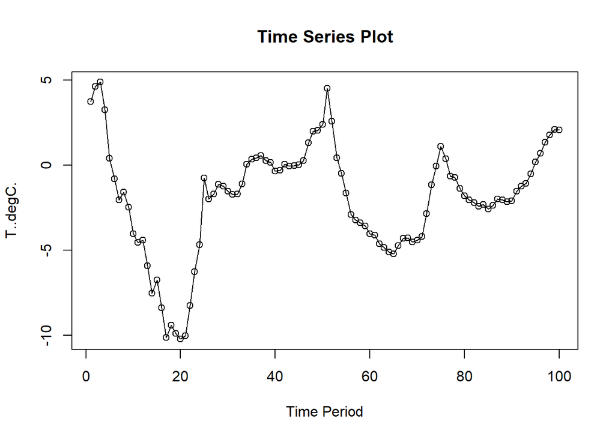

```r
ts.plot(dt.ts, xlab="Time Period", ylab="T..degC.",
        main = "Time Series Plot")
points(dt.ts)
```

## Moving Average

### Pembagian Data

Pembagian data latih dan data uji dilakukan dengan perbandingan 80% data latih dan 20% data uji.

```r
# hitung jumlah data
n <- nrow(dt)

# tentukan batas 80%
n_train <- floor(0.8 * n)

# bagi data
training_ma <- dt[1:n_train, ]
testing_ma  <- dt[(n_train+1):n, ]

# ubah ke time series
train_ma.ts <- ts(training_ma$T..degC.)
test_ma.ts  <- ts(testing_ma$T..degC.)
```

Eksplorasi data dilakukan pada keseluruhan data, data latih serta data uji menggunakan plot data deret waktu.

```r
#eksplorasi keseluruhan data
plot(dt.ts, col="red",main="Plot semua data")
points(dt.ts)
```

[output not shown]

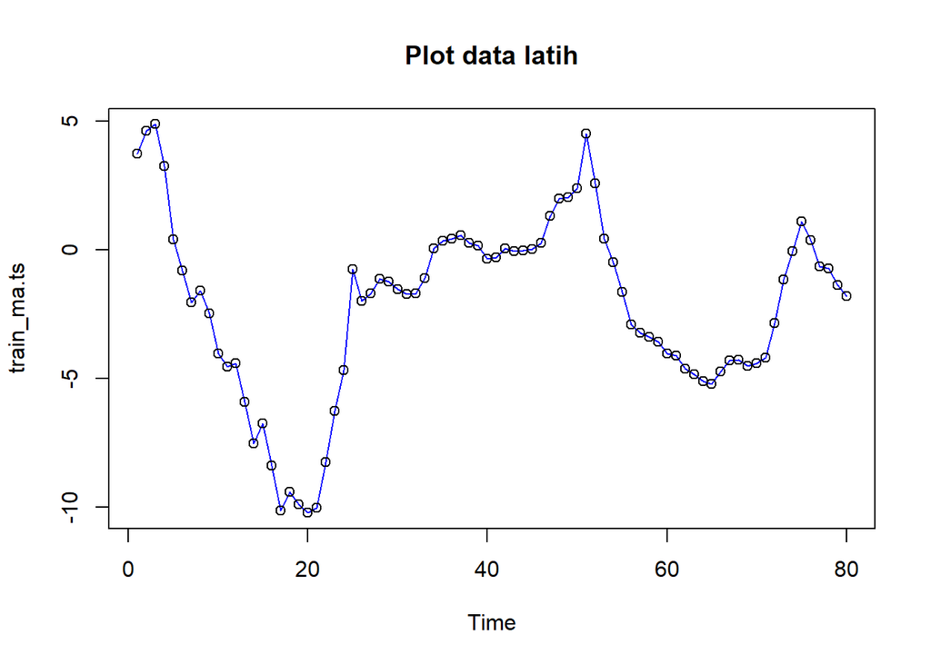

```r
#eksplorasi data latih
plot(train_ma.ts, col="blue",main="Plot data latih")
points(train_ma.ts)
```

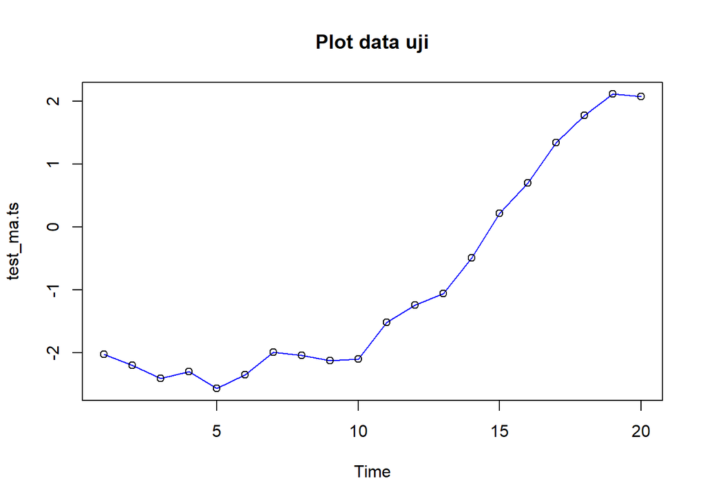

```r
#eksplorasi data uji
plot(test_ma.ts, col="blue",main="Plot data uji")
points(test_ma.ts)
```

```r
ggplot() +
  geom_line(data = training_ma, aes(x = Period, y = T..degC., col = "Data Latih")) +
  geom_line(data = testing_ma, aes(x = Period, y = T..degC., col = "Data Uji")) +
  labs(x = "Periode Waktu", y = "T..degC.", color = "Legend") +
   scale_colour_manual(name="Keterangan:", breaks = c("Data Latih", "Data Uji"),
                      values = c("blue", "red")) +
  theme_bw() + theme(legend.position = "bottom",
                     plot.caption = element_text(hjust=0.5, size=12))
```

[output not shown]

### Single Moving Average (SMA)

Pemulusan menggunakan metode SMA dilakukan dengan fungsi `SMA()`. Dalam hal ini akan dilakukan pemulusan dengan parameter `m=3`.

```r
data.sma<-SMA(train_ma.ts, n=3)
data.sma
```

```
## Time Series:
## Start = 1
## End = 80
## Frequency = 1
##  [1]            NA            NA   4.423333333   4.256666667   2.853333333
##  [6]   0.956666667  -0.803333333  -1.466666667  -2.020000000  -2.680000000
## [11]  -3.666666667  -4.316666667  -4.946666667  -5.946666667  -6.720000000
## [16]  -7.550000000  -8.413333333  -9.303333333  -9.800000000  -9.830000000
## [21] -10.033333333  -9.490000000  -8.173333333  -6.396666667  -3.893333333
## [26]  -2.470000000  -1.473333333  -1.603333333  -1.353333333  -1.293333333
## [31]  -1.490000000  -1.640000000  -1.503333333  -0.906666667  -0.220000000
## [36]   0.293333333   0.460000000   0.433333333   0.340000000   0.033333333
## [41]  -0.160000000  -0.196666667  -0.096666667  -0.003333333  -0.006666667
## [46]   0.106666667   0.553333333   1.203333333   1.786666667   2.140000000
## [51]   2.983333333   3.163333333   2.513333333   0.846666667  -0.556666667
## [56]  -1.666666667  -2.576666667  -3.156666667  -3.383333333  -3.656666667
## [61]  -3.900000000  -4.246666667  -4.516666667  -4.853333333  -5.053333333
## [66]  -5.016666667  -4.746666667  -4.433333333  -4.360000000  -4.390000000
## [71]  -4.363333333  -3.810000000  -2.730000000  -1.350000000  -0.026666667
## [76]   0.483333333   0.290000000  -0.323333333  -0.903333333  -1.286666667
```

Data pemulusan pada periode ke-t selanjutnya digunakan sebagai nilai peramalan pada periode ke t+1 sehingga hasil peramalan 1 periode kedepan adalah sebagai berikut.

```r
data.ramal<-c(NA,data.sma)
data.ramal #forecast 1 periode ke depan
```

```
##  [1]            NA            NA            NA   4.423333333   4.256666667
##  [6]   2.853333333   0.956666667  -0.803333333  -1.466666667  -2.020000000
## [11]  -2.680000000  -3.666666667  -4.316666667  -4.946666667  -5.946666667
## [16]  -6.720000000  -7.550000000  -8.413333333  -9.303333333  -9.800000000
## [21]  -9.830000000 -10.033333333  -9.490000000  -8.173333333  -6.396666667
## [26]  -3.893333333  -2.470000000  -1.473333333  -1.603333333  -1.353333333
## [31]  -1.293333333  -1.490000000  -1.640000000  -1.503333333  -0.906666667
## [36]  -0.220000000   0.293333333   0.460000000   0.433333333   0.340000000
## [41]   0.033333333  -0.160000000  -0.196666667  -0.096666667  -0.003333333
## [46]  -0.006666667   0.106666667   0.553333333   1.203333333   1.786666667
## [51]   2.140000000   2.983333333   3.163333333   2.513333333   0.846666667
## [56]  -0.556666667  -1.666666667  -2.576666667  -3.156666667  -3.383333333
## [61]  -3.656666667  -3.900000000  -4.246666667  -4.516666667  -4.853333333
## [66]  -5.053333333  -5.016666667  -4.746666667  -4.433333333  -4.360000000
## [71]  -4.390000000  -4.363333333  -3.810000000  -2.730000000  -1.350000000
## [76]  -0.026666667   0.483333333   0.290000000  -0.323333333  -0.903333333
## [81]  -1.286666667
```

Selanjutnya dilakukan peramalan sebanyak 20 periode sesuai dengan jumlah data uji. Pada metode SMA, seluruh hasil peramalan untuk 20 periode ke depan akan memiliki nilai yang sama dengan hasil ramalan satu periode ke depan.

```r
data.gab<-cbind(
  aktual=c(dt.ts),
  pemulusan=c(data.sma,rep(NA,20)),
  ramalan=c(data.ramal,rep(data.ramal[length(data.ramal)],19)))

data.gab #forecast 20 periode ke depan
```

```
##        aktual     pemulusan       ramalan
##   [1,]   3.75            NA            NA
##   [2,]   4.63            NA            NA
##   [3,]   4.89   4.423333333            NA
##   [4,]   3.25   4.256666667   4.423333333
##   [5,]   0.42   2.853333333   4.256666667
##   [6,]  -0.80   0.956666667   2.853333333
##   [7,]  -2.03  -0.803333333   0.956666667
##   [8,]  -1.57  -1.466666667  -0.803333333
##   [9,]  -2.46  -2.020000000  -1.466666667
##  [10,]  -4.01  -2.680000000  -2.020000000
##  [11,]  -4.53  -3.666666667  -2.680000000
##  [12,]  -4.41  -4.316666667  -3.666666667
##  [13,]  -5.90  -4.946666667  -4.316666667
##  [14,]  -7.53  -5.946666667  -4.946666667
```

[output cut: 86 more lines]

Adapun plot data deret waktu dari hasil peramalan yang dilakukan adalah sebagai berikut.

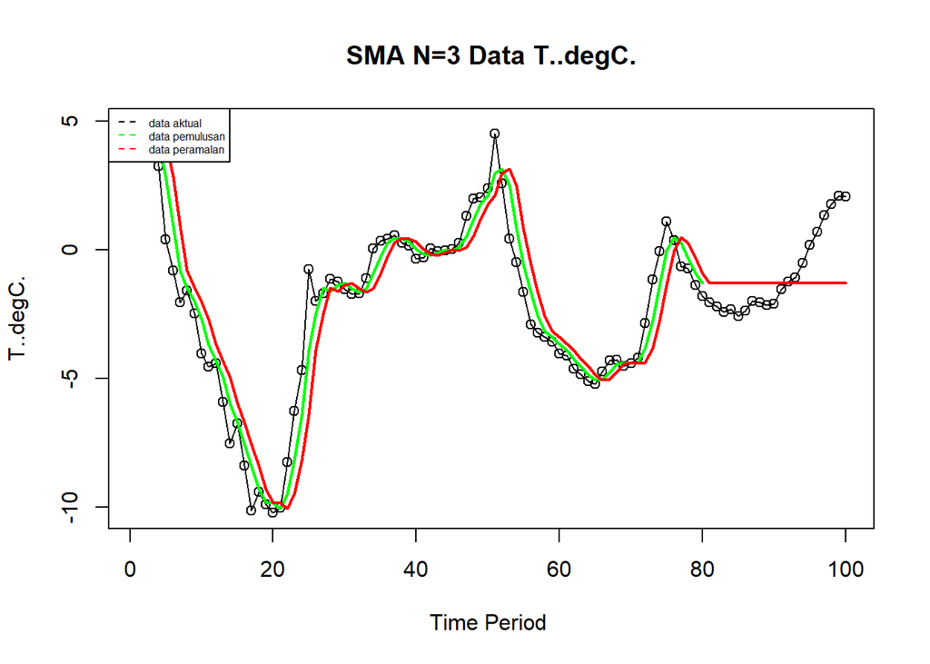

```r
ts.plot(dt.ts, xlab="Time Period ", ylab="T..degC.", main= "SMA N=3 Data T..degC.")
points(dt.ts)
lines(data.gab[,2],col="green",lwd=2)
lines(data.gab[,3],col="red",lwd=2)
legend("topleft",c("data aktual","data pemulusan","data peramalan"), lty=8, col=c("black","green","red"), cex=0.5)
```

Selanjutnya perhitungan akurasi dilakukan dengan ukuran akurasi *Sum Squares Error* (SSE), *Mean Square Error* (MSE) dan *Mean Absolute Percentage Error* (MAPE). Perhitungan akurasi dilakukan baik pada data latih maupun pada data uji.

$$SSE = \sum_{t=1}^{n} (y_t -
\hat{y}_t)^2$$

$$MSE = \frac{1}{n} \sum_{t=1}^{n} (y_t -
\hat{y}_t)^2$$

$$MAPE = \frac{1}{n} \sum_{t=1}^{n}
\left|\frac{y_t - \hat{y}_t}{y_t}\right| * 100$$

#### Akurasi Data Latih

```r
#Menghitung nilai keakuratan data latih
error_train.sma = train_ma.ts-data.ramal[1:length(train_ma.ts)]

SSE_train.sma = sum(error_train.sma[4:length(train_ma.ts)]^2)
MSE_train.sma = mean(error_train.sma[4:length(train_ma.ts)]^2)
MAPE_train.sma = mean(abs((error_train.sma[4:length(train_ma.ts)]/train_ma.ts[4:length(train_ma.ts)])*100))

akurasi_train.sma <- matrix(c(SSE_train.sma, MSE_train.sma, MAPE_train.sma))
row.names(akurasi_train.sma)<- c("SSE", "MSE", "MAPE")
colnames(akurasi_train.sma) <- c("Akurasi m = 3")
akurasi_train.sma
```

```
##      Akurasi m = 3
## SSE     208.214378
## MSE       2.704083
## MAPE    215.666431
```

#### Akurasi Data Uji

```r
#Menghitung nilai keakuratan data uji
error_test.sma = test_ma.ts-data.gab[81:100,3]

SSE_test.sma = sum(error_test.sma^2)
MSE_test.sma = mean(error_test.sma^2)
MAPE_test.sma = mean(abs((error_test.sma/test_ma.ts*100)))

akurasi_test.sma <- matrix(c(SSE_test.sma, MSE_test.sma, MAPE_test.sma))
row.names(akurasi_test.sma)<- c("SSE", "MSE", "MAPE")
colnames(akurasi_test.sma) <- c("Akurasi m = 3")
akurasi_test.sma
```

```
##      Akurasi m = 3
## SSE      54.864656
## MSE       2.743233
## MAPE    115.301057
```

### Double Moving Average (DMA)

Metode pemulusan Double Moving Average (DMA) pada dasarnya mirip dengan SMA. Namun demikian, metode ini lebih cocok digunakan untuk pola data trend. Proses pemulusan dengan rata rata dalam metode ini dilakukan sebanyak 2 kali.

- **Tahap I:**

$$S_{1,t} = \frac{1}{m} \sum_{i=t-m+1}^{t}
X_i$$

- **Tahap II:**

$$S_{2,t} = \frac{1}{m} \sum_{i=t-m+1}^{t}
S_{1,i}$$

Forecast $h$ langkah ke depan dihitung dengan:

$$F_{2,t,t+h} = A_t + B_t
\,(h)$$

dengan komponen level ($A_t$) dan tren ($B_t$):

$$A_t = 2S_{1,t} - S_{2,t}
\qquad\text{dan}\qquad
B_t = \frac{2}{m-1}\,\big(S_{1,t} - S_{2,t}\big)$$

```r
dma <- SMA(data.sma, n = 3)
At <- 2*data.sma - dma
Bt <- 2/(3-1)*(data.sma - dma)
data.dma<- At+Bt
data.ramal2<- c(NA, data.dma)

t = 1:20
f = c()

for (i in t) {
  f[i] = At[length(At)] + Bt[length(Bt)]*(i)
}

data.gab2 <- cbind(aktual = c(dt.ts),
                   pemulusan1 = c(data.sma,rep(NA,20)),
                   pemulusan2 = c(dma, rep(NA,20)),
                   At = c(At, rep(NA,20)),
                   Bt = c(Bt,rep(NA,20)),
                   ramalan = c(data.ramal2, f[-1]))
data.gab2
```

```
##        aktual    pemulusan1  pemulusan2           At           Bt      ramalan
##   [1,]   3.75            NA          NA           NA           NA           NA
##   [2,]   4.63            NA          NA           NA           NA           NA
##   [3,]   4.89   4.423333333          NA           NA           NA           NA
##   [4,]   3.25   4.256666667          NA           NA           NA           NA
##   [5,]   0.42   2.853333333  3.84444444   1.86222222 -0.991111111           NA
##   [6,]  -0.80   0.956666667  2.68888889  -0.77555556 -1.732222222   0.87111111
##   [7,]  -2.03  -0.803333333  1.00222222  -2.60888889 -1.805555556  -2.50777778
##   [8,]  -1.57  -1.466666667 -0.43777778  -2.49555556 -1.028888889  -4.41444444
##   [9,]  -2.46  -2.020000000 -1.43000000  -2.61000000 -0.590000000  -3.52444444
##  [10,]  -4.01  -2.680000000 -2.05555556  -3.30444444 -0.624444444  -3.20000000
##  [11,]  -4.53  -3.666666667 -2.78888889  -4.54444444 -0.877777778  -3.92888889
##  [12,]  -4.41  -4.316666667 -3.55444444  -5.07888889 -0.762222222  -5.42222222
##  [13,]  -5.90  -4.946666667 -4.31000000  -5.58333333 -0.636666667  -5.84111111
##  [14,]  -7.53  -5.946666667 -5.07000000  -6.82333333 -0.876666667  -6.22000000
```

[output cut: 86 more lines]

Hasil pemulusan menggunakan metode DMA divisualisasikan sebagai berikut

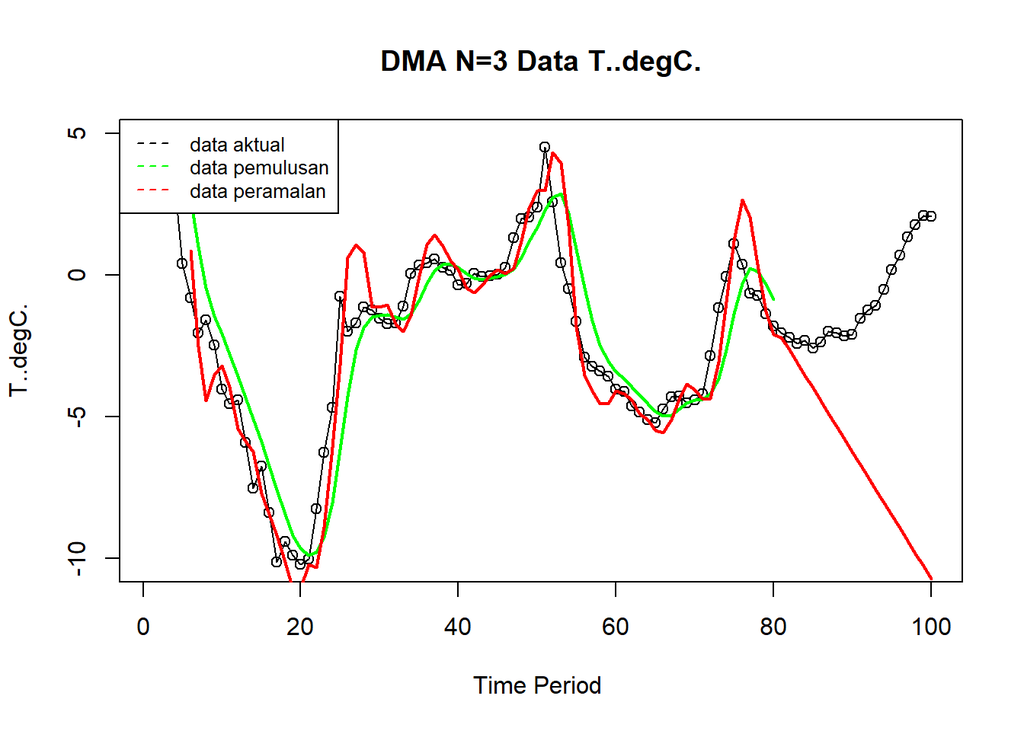

```r
ts.plot(dt.ts, xlab="Time Period ", ylab="T..degC.", main= "DMA N=3 Data T..degC.")
points(dt.ts)
lines(data.gab2[,3],col="green",lwd=2)
lines(data.gab2[,6],col="red",lwd=2)
legend("topleft",c("data aktual","data pemulusan","data peramalan"), lty=8, col=c("black","green","red"), cex=0.8)
```

Selanjutnya perhitungan akurasi dilakukan baik pada data latih maupun data uji. Perhitungan akurasi dilakukan dengan ukuran akurasi SSE, MSE dan MAPE.

#### Akurasi Data Latih

```r
#Menghitung nilai keakuratan data latih
error_train.dma = train_ma.ts-data.ramal2[1:length(train_ma.ts)]

SSE_train.dma = sum(error_train.dma[6:length(train_ma.ts)]^2)
MSE_train.dma = mean(error_train.dma[6:length(train_ma.ts)]^2)
MAPE_train.dma = mean(abs((error_train.dma[6:length(train_ma.ts)]/train_ma.ts[6:length(train_ma.ts)])*100))

akurasi_train.dma <- matrix(c(SSE_train.dma, MSE_train.dma, MAPE_train.dma))
row.names(akurasi_train.dma)<- c("SSE", "MSE", "MAPE")
colnames(akurasi_train.dma) <- c("Akurasi m = 3")
akurasi_train.dma
```

```
##      Akurasi m = 3
## SSE     115.354856
## MSE       1.538065
## MAPE    165.532073
```

#### Akurasi Data Uji

```r
#Menghitung nilai keakuratan data uji
error_test.dma = test_ma.ts-data.gab2[81:100,6]
SSE_test.dma = sum(error_test.dma^2)
MSE_test.dma = mean(error_test.dma^2)
MAPE_test.dma = mean(abs((error_test.dma/test_ma.ts*100)))

akurasi_test.dma <- matrix(c(SSE_test.dma, MSE_test.dma, MAPE_test.dma))
row.names(akurasi_test.dma)<- c("SSE", "MSE", "MAPE")
colnames(akurasi_test.dma) <- c("Akurasi m = 3")
akurasi_test.dma
```

```
##      Akurasi m = 3
## SSE      951.40749
## MSE       47.57037
## MAPE     602.72891
```

Berdasarkan hasil pengujian, DMA memiliki kemampuan penyesuaian yang lebih baik terhadap data latih dibandingkan SMA. Namun, performa DMA mengalami penurunan yang sangat besar pada data uji. Sebaliknya, SMA menghasilkan nilai error yang relatif stabil antara data latih dan data uji. Oleh karena itu, berdasarkan kemampuan peramalan pada data uji, SMA (m=3) lebih baik dibandingkan DMA (m=3).

## Exponential Smoothing

Metode Exponential Smoothing merupakan metode pemulusan deret waktu dengan memberikan bobot yang menurun secara eksponensial pada data historis, di mana nilai terbaru mendapat bobot lebih besar dibanding nilai yang lebih lama. Metode ini menggunakan satu atau lebih parameter pemulusan yang secara langsung menentukan besar kecilnya bobot setiap pengamatan. Pemilihan parameter yang tepat akan sangat berpengaruh terhadap hasil ramalan. Secara umum, Exponential Smoothing dibedakan menjadi dua jenis, yaitu model tunggal (single) yang digunakan untuk data tanpa tren maupun musiman, serta model ganda (double) yang mampu menangkap adanya tren pada data.

### Pembagian Data

Pembagian data latih dan data uji dilakukan dengan perbandingan 80% data latih dan 20% data uji.

```r
# jumlah baris data
n <- nrow(dt)

# hitung batas 80%
n_train <- floor(0.8 * n)

# bagi data
training <- dt[1:n_train, ]
testing  <- dt[(n_train+1):n, ]

# ubah ke time series
train.ts <- ts(training$T..degC.)
test.ts  <- ts(testing$T..degC.)
```

### Eksplorasi

Eksplorasi dilakukan dengan membuat plot data deret waktu untuk keseluruhan data, data latih, dan data uji.

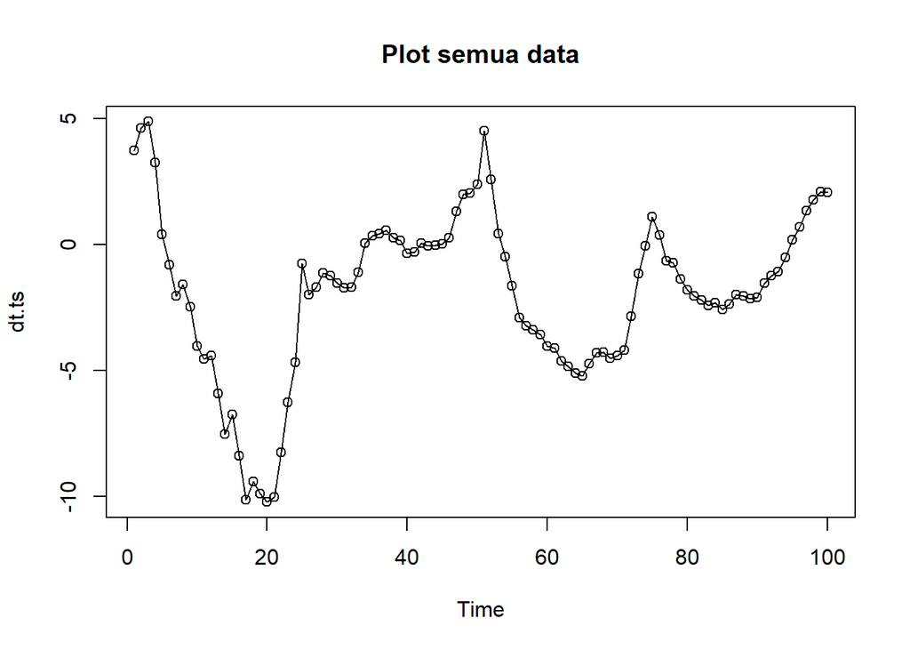

```r
#eksplorasi data
plot(dt.ts, col="black",main="Plot semua data")
points(dt.ts)
```

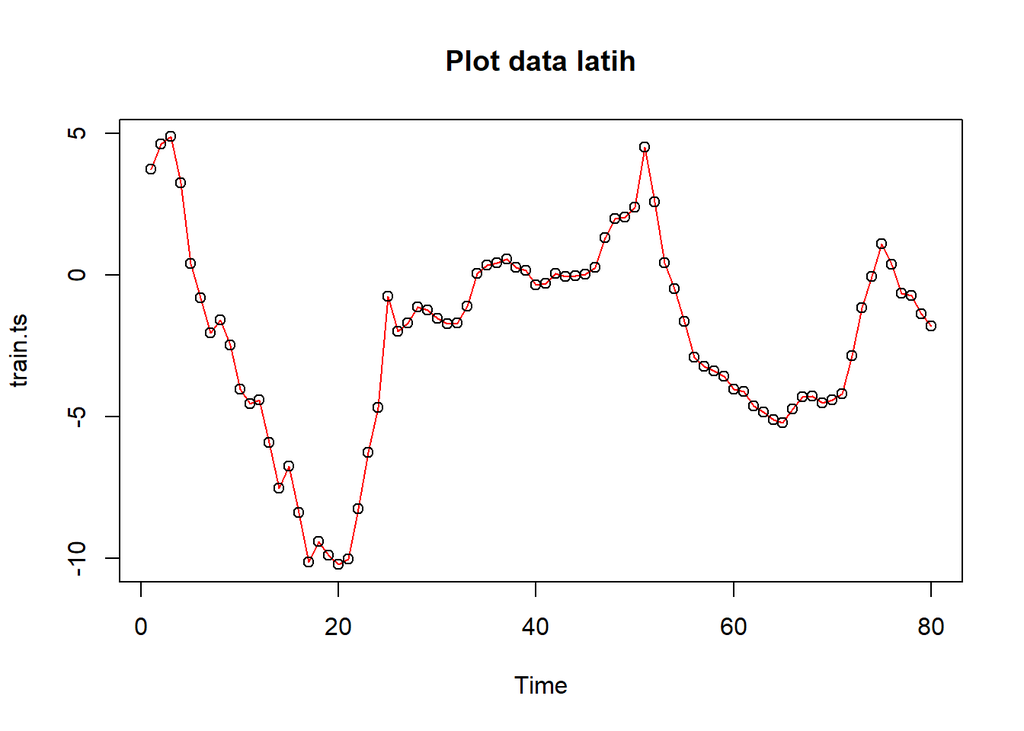

```r
plot(train.ts, col="red",main="Plot data latih")
points(train.ts)
```

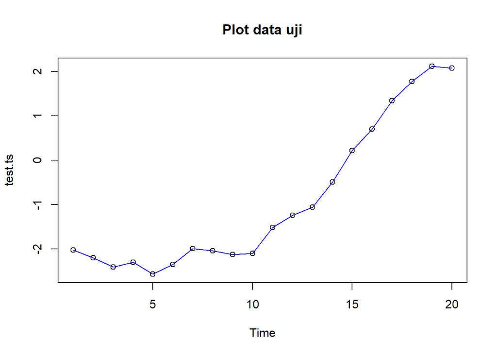

```r
plot(test.ts, col="blue",main="Plot data uji")
points(test.ts)
```

```r
ggplot() +
  geom_line(data = training, aes(x = Period, y = T..degC., col = "Data Latih")) +
  geom_line(data = testing, aes(x = Period, y = T..degC., col = "Data Uji")) +
  labs(x = "Periode Waktu", y = "T..degC.", color = "Legend") +
  scale_colour_manual(name="Keterangan:", breaks = c("Data Latih", "Data Uji"),
                      values = c("blue", "red")) +
  theme_bw() + theme(legend.position = "bottom",
                     plot.caption = element_text(hjust=0.5, size=12))
```

[output not shown]